# Lernzielmatrix - Kurzübersicht

Von einer die auszog etwas zu visualisieren.

Author

Sandra Zänkert

Load packages

```r
library(xlsx)
library(tidyverse)
library(ggplot2)
library(RColorBrewer)
library(kableExtra)
library(grateful)
```

Load data

```r
data <- as.data.frame(read.xlsx("data/EXCEL_full.xlsx", 1))
```

## Lernzielmatrix

**Tip**

Codierung der Kompetenzbereiche:

SK = Sachkompetenz; MK = Methodenkompetenz; SoK = Sozialkompetenz; SeK = Selbstkompetenz

Codierung der Lernniveaustufen:

1 = Erinnern/Wissen; 2 = Verstehen; 3 = Anwenden; 4 = Analysieren; 5 = Beurteilen; 6 = Erschaffen

In einem ersten Schritt wurde die Tabelle als CSV von Zenodo geladen und in ein auswertbares Format gebracht. Hierzu wurden mittels eines Python-Skripts die Kompetenzbereiche und Lernstufen in eigene Spalten transferiert.

**Note**

Die CSV-Tabelle war nicht gut einlesbar, da bspw. die Kompetenzbereiche und Lernstufen teils mit und teils ohne Leerzeichen voneinander getrennt waren. Daher mussten im Python-Code einige “Ausnahmen” berücksichtig werden.

Als Resultat ergab sich eine Tabelle mit dem Header:

```r
data %>%
  select(!"NA.") %>%
  head(n=1) %>%
  kbl()
```

| FDM.Themenbereich | FDM.Sub.Themenbereich | Level | Lernziel | Kompentenzbereich | Lernstufe |
| --- | --- | --- | --- | --- | --- |
| Grundlagen und übergreifende Konzepte | Allgemeine Grundsätze und Konzepte des Forschungsdaten-managements | Bachelor | Lernende können die Relevanz und Vor- und Nachteile von FDM für die Forschung allgemein sowie für die eigene Forschung beschreiben. | SK | 2 |

**Note**

Bei dieser Ansicht fällt u.a. auf, dass es fehlende Werte bei den Lernzielen gibt (s. Data Stewards: “Recht und Ethik” und “Unterstützungsstruktur”).

**Bachelor**

**Grundlagen und übergreifende Konzepte**

```r
data %>%
  filter(Level == "Bachelor" & FDM.Themenbereich == "Grundlagen und übergreifende Konzepte") %>%
  select(!c("NA.", "FDM.Themenbereich", "Level")) %>%
  kbl() %>%
  kableExtra::collapse_rows(columns = c(1,2), valign = "top")
```

| FDM.Sub.Themenbereich | Lernziel | Kompentenzbereich | Lernstufe |
| --- | --- | --- | --- |
| Allgemeine Grundsätze und Konzepte des Forschungsdaten-managements | Lernende können die Relevanz und Vor- und Nachteile von FDM für die Forschung allgemein sowie für die eigene Forschung beschreiben. | SK | 2 |
|  |  | SeK | 1 |
|  | Lernende können die Definition von Forschungsdaten wiedergeben und verschiedene Formen von Forschungsdaten benennen. | SK | 1 |
|  | Lernende können den FDL-Zyklus beschreiben und dessen Stationen benennen. | SK | 1 |
| Forschungsdaten-Policies | Lernende können erklären, was eine Policy ist. | SK | 1 |
|  | Lernende können beschreiben, was eine Forschungsdaten-Policy ist. | SK | 1 |
|  | Lernende können die Funktion einer Forschungsdaten-Policy beschreiben. | SK | 2 |
| Datenmanagementpläne | Lernende können beschreiben, was ein DMP ist. | SK | 2 |
|  | Lernende können Komponenten eines DMP aufzählen. | SK | 1 |
|  | Lernende können die Relevanz eines DMP als Planungsinstrument beschreiben. | SK | 2 |
| FAIR-Prinzipien | Lernende können die FAIR-Prinzipien benennen. | SK | 1 |
|  | Lernende können die einzelnen Aspekte von FAIR beschreiben. | SK | 1 |
| Open X (Open Data, Open Source, Open Science, etc.) | Lernende können das Konzept "Open Science" erläutern. | SK | 1 |
|  | Lernende können die Begriffe Open Access, Open Data, Open Source als Bereiche bzw. Praktiken der Open Science beschreiben. | SK | 1 |
|  | Lernende können die Vor- und Nachteile von Open Science und zugehöriger Praktiken benennen. | SK | 2 |

**Arbeiten mit Daten**

```r
data %>%
  filter(Level == "Bachelor" & FDM.Themenbereich == "Arbeiten mit Daten") %>%
  select(!c("NA.", "FDM.Themenbereich", "Level")) %>%
  kbl() %>%
  kableExtra::collapse_rows(columns = c(1,2), valign = "top")
```

| FDM.Sub.Themenbereich | Lernziel | Kompentenzbereich | Lernstufe |
| --- | --- | --- | --- |
| Ordnung und Struktur, Versionierung | Lernende können beschreiben, was eine Dateibenennungskonvention ist. | SK | 1 |
|  | Lernende können die Relevanz strukturierter Dateibenennung beschreiben. | SK | 2 |
|  | Lernende können Kriterien für eine gute Benennungskonvention nennen. | SK | 2 |
|  | Lernende können unter Anleitung Benennungskonventionen entwickeln und auf eigene (und kollaborativ) genutzte Forschungsdaten anwenden. | MK | 3 |
|  | Lernende können die allgemeinen Merkmale einer effizienten Ordnerstruktur beschreiben. | SK | 1 |
|  | Lernende können den Nutzen einer klaren, nachvollziehbaren Ordnerstruktur erläutern. | SK | 1 |
|  | Lernende können unter Anleitung eine Ordnerstruktur für eigene und kollaborative Forschungsdaten entwerfen. | MK | 3 |
|  | Lernende können unter Anleitung Ordnerstrukturen und Benennungskonventionen dokumentieren. | SK | 3 |
|  |  | MK | 2 |
|  | Lernende können den Zweck und Nutzen von Versionierung beschreiben. | SK | 1 |
|  | Lernende können einfache Versionierungsmethoden für Forschungsdaten benennen. | SK | 3 |
|  | Lernende können unterstützende Werkzeuge (Umbenennungswerkzeuge) benennen. | SK | 2 |
|  | Lernende können erläutern, warum Rohdaten separat gespeichert werden sollten. | SK | 2 |
| Daten, Datentypen, Datenformate | Lernende können die Unterschiede zwischen den Begriffen: Datentypen und Datenformaten/Dateiformaten und Dateityp beschreiben. | SK | 1 |
|  | Lernende können einfache Datentypen nennen. | SK | 1 |
|  | Lernende können verschiedene Dateiformate identifizieren und Dateitypen zuordnen. | SK | 3 |
|  | Lernende können den Unterschied zwischen quantitativen und qualitativen Daten beschreiben. | SK | 2 |
| Datenspeicherung und Backup | Lernende können verschiedene Speichersysteme benennen. | SK | 1 |
|  | Lernende können erklären, was ein Backup ist. | SK | 2 |
|  | Lernende können darstellen, warum man Backups nutzen sollte. | SK | 2 |
|  | Lernende können die 3-2-1-Regel in eigenen Worten wiedergeben. | SK | 2 |
| Datensicherheit | Lernende können allgemeine Anforderungen an Datenschutz und Zugangskontrolle nennen. | SK | 1 |
|  | Lernende können Beispiele für Richtlinien zu Zugangskontrollen nennen. | SK | 1 |
| Datenqualität | Lernende können Datenqualität und ihre Parameter definieren. | SK | 1 |
|  | Lernende können verschiedene Aspekte von Datenqualität (inhaltsbezogen, kontextbezogen, darstellungsbezogen und zugangsbezogen) erläutern. | SK | 1 |
|  | Lernende können Maßnahmen zur Qualitätsverbesserung von Daten aufzählen. | MK | 1 |
|  | Lernende können Strategien zur Fehlervermeidung beim Umgang mit Daten beschreiben. | SK | 2 |
|  | Lernende können Daten strukturiert in Tabellenform ablegen, so dass sie von Analysewerkzeugen gut verwertet werden können. | MK | 3 |
| Tools | Lernende können verschiedene hilfreiche Tools zum Datenmanagement (in verschiedenen Forschungsphasen) benennen. | SK | 1 |
|  | Lernende können ihren individuellen Ansprüchen und Aufgaben entsprechende Tools recherchieren. | SK | 1 |
| (Forschungs-)Software & Coding | Lernende können geeignete Software für die Auswertung von Daten benennen. | SK | 1 |
|  | Lernende können unter Zuhilfenahme geeigneter Software aus vorliegenden Daten grundlegende Kennwerte berechnen. | MK | 3 |
|  | Lernende können unter Zuhilfenahme geeigneter Software vorliegende Daten grafisch darstellen. | MK | 3 |

**Dokumentation und Metadaten**

```r
data %>%
  filter(Level == "Bachelor" & FDM.Themenbereich == "Dokumentation und Metadaten") %>%
  select(!c("NA.", "FDM.Themenbereich", "Level")) %>%
  kbl() %>%
  kableExtra::collapse_rows(columns = c(1,2), valign = "top")
```

| FDM.Sub.Themenbereich | Lernziel | Kompentenzbereich | Lernstufe |
| --- | --- | --- | --- |
| Datendokumentation | Lernende können beschreiben, was eine Datendokumentation ist. | SK | 1 |
|  | Lernende können erläutern, welche Funktionen eine Datendokumentation erfüllt. | SK | 2 |
|  | Lernende können Komponenten/Inhalte einer Datendokumentation beschreiben. | SK | 1 |
|  | Lernende können angeleitet einfache Datendokumentationen für eigene Forschungsdaten formulieren. | MK | 3 |
|  | Lernende können verschiedene Werkzeuge und Methoden zur Dokumentation benennen. | SK | 1 |
| Metadaten und Metadatenstandards | Lernende können die Begriffe Metadaten, Normdaten und kontrolliertes Vokabular erläutern. | SK | 1 |
|  | Lernende können den Nutzen der Verwendung von Metadaten beschreiben. | SK | 2 |
|  | Lernende können erläutern, was ein Metadatenstandard ist. | SK | 1 |
|  | Lernende können erläutern, welche Funktionen Metadaten (insb. für die Nachnutzung von Daten) haben. | SK | 1 |
| Persistente Identifikatoren | Lernende können beschreiben, was ein PID ist. | SK | 1 |
| Definition persistente Identifikatoren (PID); Vor- und Nachteile von PIDs; Funktionen von PIDs; nähere Beschreibung ausgewählter PIDs; Aufbau von PIDs | Lernende können Beispiele für verschiedene PIDs benennen. | SK | 1 |
| Ontologien und kontrollierte Vokabulare | Lernende können die Rolle von Ontologien und Vokabularen erklären. | SK | 1 |

**Langzeitarchivierung, Publikation, Nachnutzung**

```r
data %>%
  filter(Level == "Bachelor" & FDM.Themenbereich == "Langzeitarchivierung, Publikation, Nachnutzung") %>%
  select(!c("NA.", "FDM.Themenbereich", "Level")) %>%
  kbl() %>%
  kableExtra::collapse_rows(columns = c(1,2), valign = "top")
```

| FDM.Sub.Themenbereich | Lernziel | Kompentenzbereich | Lernstufe |
| --- | --- | --- | --- |
| Langzeitarchivierung von Daten | Lernende können Kriterien nennen, nach denen Forschungsdaten für eine LZA ausgewählt werden sollten. | SK | 1 |
|  | Lernende können sich mit Fragen zur Nachhaltigkeit von Forschungsdaten kritisch auseinandersetzen. | SK | 2 |
| Publikationswege für Daten | Lernende können erläutern, was eine Datenpublikation ist. | SK | 1 |
|  | Lernende können Bestandteile einer Datenpublikation nennen. | SK | 2 |
|  | Lernende können verschiedene Publikationswege für Daten nennen. | SK | 2 |
|  | Lernende können Vor- und Nachteile einer Datenpublikation aufzählen. | SK | 2 |
| Repositorien | Lernende können erläutern, was ein Repositorium ist. | SK | 1 |
|  | Lernende können verschiedene Arten von Repositorien benennen. | SK | 2 |
|  | Lernende können Vor- und Nachteile verschiedener Datenrepositorien benennen. | SK | 2 |
|  | Lernende können unter Anleitung nach und in Repositorien nach Daten suchen. | MK | 2 |
| Daten nachnutzen | Lernende können die Vor- und Nachteile der Nachnutzung von Daten benennen. | SK | 2 |
|  | Lernende können die Voraussetzungen zur Nachnutzung von Daten benennen. | SK | 2 |
|  | Lernende können Informationsquellen für das Recherchieren nach Forschungsdaten benennen. | SK | 1 |
|  | Lernende können unter Anleitung Forschungsdaten recherchieren. | MK | 2 |
|  | Lernende können unter Anleitung Regeln des Zitierens von Forschungsdaten anwenden. | MK | 2 |

**Recht und Ethik**

```r
data %>%
  filter(Level == "Bachelor" & FDM.Themenbereich == "Recht und Ethik") %>%
  select(!c("NA.", "FDM.Themenbereich", "Level")) %>%
  kbl() %>%
  kableExtra::collapse_rows(columns = c(1,2), valign = "top")
```

| FDM.Sub.Themenbereich | Lernziel | Kompentenzbereich | Lernstufe |
| --- | --- | --- | --- |
| Allgemeine rechtliche Aspekte | Lernende können die das FDM tangierenden Rechtsbereiche aufzählen. | SK | 1 |
|  | Lernende können die Rolle von Urheberrecht und Lizenzrecht im FDM erläutern. | SK | 2 |
|  | Lernende können relevante Lizenzsysteme benennen. | SK | 1 |
|  | Lernende können die Eigenschaften offener und restriktiver Lizenzen beschreiben. | SK | 2 |
| Datenschutz und personenbezogene Daten | Lernende können Beweggründe für einen besonderen Schutz personenbezogener Daten nennen. | SK | 2 |
|  | Lernende können die Rechtsgrundlagen zum Schutz personenbezogener Daten benennen. | SK | 1 |
|  | Lernende können darstellen, was personenbezogene und sensible Daten sind und entsprechende Beispiele nennen. | SK | 3 |
|  | Lernende können Methoden und Maßnahmen benennen, die die Identität von Forschungsteilnehmenden schützen. | SK | 2 |
|  | Lernende können die Hinweispflichten, die für die Erhebung personenbezogener Daten für Forschungszwecke gelten, nennen. | SK | 2 |
|  | Lernende können die Bedeutung der Datensicherheit für den Datenschutz erläutern. | SK | 2 |
| Informierte Einwilligung | Lernende können Inhalte und Bedeutung einer informierten Einwilligung beschreiben. | SK | 2 |
| Anonymisierung und Pseudonymisierung | Lernende können die Definitionen der Begriffe Anonymisierung und Pseudonymisierung wiedergeben. | SK | 1 |
|  | Lernende können den Unterschied zwischen Anonymisierung und Pseudonymisierung erläutern. | SK | 2 |
|  | Lernende können direkt identifizierende Attribute in einem Datensatz erkennen. | SK | 2 |
|  |  | MK | 2 |
|  | Lernende können verschiedene Verfahren zur Anonymisierung und Pseudonymisierung von Daten beschreiben. | SK | 2 |
|  | Lernende können Verfahren zur Anonymisierung und Pseudonymisierung unter Anleitung auf eigene Daten anwenden. | MK | 3 |
| Ethische Aspekte und Gute Wissenschaftliche Praxis (GWP) | Lernende können ethische Dimensionen im Umgang mit Daten benennen. | SK | 1 |
|  | Lernende können einen verantwortungsvollen Umgang mit Daten beschreiben. | SK | 2 |
|  | Lernende können die Grundprinzipien Guter Wissenschaftlicher Praxis erläutern. | SK | 2 |
|  | Lernende können die CARE-Prinzipien beschreiben. | SK | 2 |

**Unterstützungsstrukturen**

```r
data %>%
  filter(Level == "Bachelor" & FDM.Themenbereich == "Unterstützungsstrukturen") %>%
  select(!c("NA.", "FDM.Themenbereich", "Level")) %>%
  kbl() %>%
  kableExtra::collapse_rows(columns = c(1,2), valign = "top")
```

| FDM.Sub.Themenbereich | Lernziel | Kompentenzbereich | Lernstufe |
| --- | --- | --- | --- |
| Relevante Infrastrukturen | Lernende können Ansprechpersonen/Abteilungen zum FDM an ihren Institutionen benennen. | SK | 2 |

**Master**

**Grundlagen und übergreifende Konzepte**

```r
data %>%
  filter(Level == "Master" & FDM.Themenbereich == "Grundlagen und übergreifende Konzepte") %>%
  select(!c("NA.", "FDM.Themenbereich", "Level")) %>%
  kbl() %>%
  kableExtra::collapse_rows(columns = c(1,2), valign = "top")
```

| FDM.Sub.Themenbereich | Lernziel | Kompentenzbereich | Lernstufe |
| --- | --- | --- | --- |
| Allgemeine Grundsätze und Konzepte des Forschungsdaten-managements | Lernende können Maßnahmen für gutes FDM in verschiedenen Stationen des FDL-Zyklus beschreiben. | SK | 2 |
|  | Lernende können die Relevanz und Vor- und Nachteile von FDM diskutieren. | SK | 2 |
|  |  | SoK | 2 |
|  |  | SeK | 2 |
|  | Lernende können allgemeine Problemstellungen im Bereich des FDM benennen. | SK | 2 |
|  | Lernende können eigene Tätigkeiten in einem Forschungsprozess den Stationen des FDL-Zyklus zuordnen. | SK | 2 |
|  |  | SeK | 2 |
| Forschungsdaten-Policies | Lernende können den Unterschied zwischen disziplinären und institutionellen Forschungsdaten-Policies erläutern. | SK | 2 |
|  | Lernende können Forschungsdaten-Policies kritisch diskutieren. | SK | 4 |
|  |  | SoK | 4 |
|  |  | SeK | 3 |
| Datenmanagementpläne | Lernende können unter Anleitung einfache DMPs für eigene Projekte erstellen. | SK | 2 |
|  |  | MK | 3 |
|  | Lernende können Vor- und Nachteile eines DMP kritisch diskutieren. | SK | 2 |
|  |  | SoK | 3 |
| FAIR-Prinzipien | Lernende können Vor- und Nachteile von FAIRen Daten diskutieren. | SK | 2 |
|  |  | MK | 3 |
|  |  | SoK | 3 |
|  | Lernende können FAIRness von Daten einschätzen. | SK | 3 |
|  |  | MK | 2 |
| Open X (Open Data, Open Source, Open Science, etc.) | Lernende können zwischen den Konzepten "FAIR" und "Open" differenzieren. | SK | 3 |
|  | Lernende können beurteilen, ob eine Veröffentlichung frei zugänglich ist. | SK | 4 |
|  | Lernende können eigenständig Plattformen für offene Daten finden. | MK | 4 |
|  | Lernende können beschreiben, was erforderlich ist, um Forschungsdaten offen zugänglich zu machen. | SK | 3 |

**Arbeiten mit Daten**

```r
data %>%
  filter(Level == "Master" & FDM.Themenbereich == "Arbeiten mit Daten") %>%
  select(!c("NA.", "FDM.Themenbereich", "Level")) %>%
  kbl() %>%
  kableExtra::collapse_rows(columns = c(1,2), valign = "top")
```

| FDM.Sub.Themenbereich | Lernziel | Kompentenzbereich | Lernstufe |
| --- | --- | --- | --- |
| Ordnung und Struktur, Versionierung | Lernende können eigenständig Benennungskonventionen entwickeln und auf eigene (und kollaborativ) genutzte Forschungsdaten anwenden. | MK | 4 |
|  | Lernende können Dateibenennungen und Dateibenennungskonventionen kritisch bewerten. | SK | 3 |
|  | Lernende können eigenständig eine Ordnerstruktur für eigene und kollaborative Forschungsdaten entwerfen und auf eigene (und kollaborativ) genutzte Forschungsdaten anwenden. | SK | 3 |
|  |  | MK | 4 |
|  | Lernende können verschiedene Ordnerstrukturen für Dateien kritisch bewerten. | SK | 3 |
|  | Lernende können eigenständig Ordnerstrukturen und Benennungskonventionen dokumentieren. | MK | 3 |
|  | Lernende können Methoden und Werkzeuge für die Versionskontrolle benennen. | SK | 1 |
|  | Lernende können einfache Versionierungsmethoden auf eigene Forschungsdatendaten anwenden. | MK | 3 |
|  | Lernende können unterstützende Werkzeuge (Umbenennungswerkzeuge) auf eigene Dateien anwenden. | SK | 2 |
| Daten, Datentypen, Datenformate | Lernende können beschreiben, was ein Datenstandard ist. | SK | 2 |
|  | Lernende können geeignete Dateiformate für die Archivierung und Nachnutzung nennen. | SK | 2 |
|  | Lernende können die Vor- und Nachteile verschiedener Dateiformate (im Hinblick auch Interoperabilität und Nachnutzung) gegenüberstellen. | SK | 4 |
|  | Lernende können unter Anleitung geeignete Formate für Archivierung und Nachnutzung auswählen. | MK | 3 |
|  | Lernende können eigene Daten unter Anleitung in nachnutzbaren Formaten anlegen oder in entsprechende Formate überführen. | MK | 3 |
|  | Lernende können sich mit Fragen zur Nachhaltigkeit von Dateiformaten kritisch auseinandersetzen. | SK | 4 |
|  | Lernende können unter Anleitung Werkzeuge zur Dateiformaterkennung und -validierung nutzen. | MK | 3 |
|  | Lernende können unter Anleitung angemessene Verfahrensweisen für quantitative und qualitative Daten zuordnen. | SK | 3 |
|  |  | MK | 3 |
| Datenspeicherung und Backup | Lernende können beschreiben, für welche Anforderungen und Anwendungsszenarien welche Speichersysteme geeignet sind. | SK | 3 |
|  | Lernende können den Nutzen und die Risiken verschiedener Speichersysteme und unterschiedlicher Speicherorganisation aufzählen. | SK | 1 |
|  | Lernende können unter Anleitung eine eigene Backup-Strategie entwickeln und anwenden. | MK | 3 |
|  | Lernende können die 3-2-1-Regel auf ihre eigenen Daten anwenden. | SK | 3 |
|  | Lernende können verschiedene institutionelle Backup-Lösungen auflisten. | SK | 1 |
| Datensicherheit | Lernende können den Inhalt von Richtlinien in Bezug auf Datenschutz beschreiben. | SK | 1 |
|  | Lernende können den Inhalt von Richtlinien in Bezug auf Zugriffskontrolle beschreiben. | SK | 1 |
|  | Lernende können die Verwendung von Richtlinien in Bezug auf Datenschutz erläutern. | SK | 2 |
|  | Lernende können die Verwendung von Richtlinien in Bezug auf Zugriffskontrolle erläutern. | SK | 2 |
|  | Lernende können darlegen, warum Datenschutz im Kontext des FDM notwendig ist. | SK | 2 |
| Datenqualität | Lernende können den Begriff "Datenqualität" bezogen auf ihre Daten erläutern. | MK | 3 |
|  | Lernende können qualitative Mängel in eignen und fremden Daten identifizieren. | MK | 4 |
|  | Lernende können identifizierte Qualitätsmängel in ihren Daten unter Anleitung korrigieren. | SK | 3 |
|  |  | MK | 3 |
|  | Lernende können Strategien zur Fehlervermeidung beim Umgang mit Daten beschreiben und anwenden. | SK | 3 |
| Tools | Lernende können ... verschiedene hilfreiche Tools zum Datenmanagement unter Anleitung (in verschiedenen Forschungsphasen) anwenden. | MK | 3 |
| (Forschungs-)Software & Coding | Lernende können unter Zuhilfenahme geeigneter Software (selbst erhobene) Daten analysieren. | MK | 4 |
|  | Lernende können unter Zuhilfenahme geeigneter Software (selbst erhobene) Daten grafisch auswerten. | MK | 4 |

**Dokumentation und Metadaten**

```r
data %>%
  filter(Level == "Master" & FDM.Themenbereich == "Dokumentation und Metadaten") %>%
  select(!c("NA.", "FDM.Themenbereich", "Level")) %>%
  kbl() %>%
  kableExtra::collapse_rows(columns = c(1,2), valign = "top")
```

| FDM.Sub.Themenbereich | Lernziel | Kompentenzbereich | Lernstufe |
| --- | --- | --- | --- |
| Datendokumentation | Lernende können nachvollziehbare Argumente und Kriterien für eine nachhaltige Datendokumentation benennen. | SK | 2 |
|  | Lernende können anhand von Beispielen Vor- und Nachteile verschiedener Dokumentationsformen beschreiben. | SK | 5 |
|  | Lernende können eigenständig einfache Datendokumentationen erstellen. | MK | 3 |
| Metadaten und Metadatenstandards | Lernende können verschiedene Metadatenstandards benennen. | SK | 1 |
|  | Lernende können unter Anleitung Metadatenstandards finden. | MK | 2 |
|  | Lernende können ihre Daten auf Basis vorgegebener, einfacher Standards mit Metadaten beschreiben. | MK | 3 |
|  | Lernende können Metadaten auslesen. | MK | 3 |
| Persistente Identifikatoren | Lernende können den allgemeinen Aufbau eines PID beschreiben. | SK | 2 |
| Definition persistente Identifikatoren (PID); Vor- und Nachteile von PIDs; Funktionen von PIDs; nähere Beschreibung ausgewählter PIDs; Aufbau von PIDs | Lernende können PIDs für die die Recherche nutzen. | MK | 2 |
| Ontologien und kontrollierte Vokabulare | Lernende können die Verwendung von Ontologien und Vokabularen als solche einordnen. | SK | 3 |
|  | Lernende können domänenrelevante Ontologien als solche einordnen. | SK | 3 |

**Langzeitarchivierung, Publikation, Nachnutzung**

```r
data %>%
  filter(Level == "Master" & FDM.Themenbereich == "Langzeitarchivierung, Publikation, Nachnutzung") %>%
  select(!c("NA.", "FDM.Themenbereich", "Level")) %>%
  kbl() %>%
  kableExtra::collapse_rows(columns = c(1,2), valign = "top")
```

| FDM.Sub.Themenbereich | Lernziel | Kompentenzbereich | Lernstufe |
| --- | --- | --- | --- |
| Langzeitarchivierung von Daten | Lernende können besondere Vorkehrungen beschreiben, die getroffen werden müssen, damit Daten für längere Zeit verfügbar und nachnutzbar sein können. | SK | 2 |
|  | Lernende können besondere Anforderungen für eine LZA von Forschungsdaten beschreiben. | SK | 1 |
|  | Lernende können verschiedene Wege, Daten langfristig zu archivieren beschreiben. | SK | 1 |
|  | Lernende können institutionelle Lösungen (Repositorien) nennen. | SK | 1 |
|  | Lernende können unter Anleitung institutionelle Lösungen anwenden. | SK | 3 |
| Publikationswege für Daten | Lernende können Vor- und Nachteile einer Datenpublikation diskutieren. | SK | 4 |
|  |  | SoK | 3 |
|  | Lernende können eigene Daten unter Anleitung publizieren. | MK | 3 |
| Repositorien | Lernende können eigenständig nach und in Repositorien nach Daten suchen. | MK | 3 |
| Daten nachnutzen | Lernende können verschiedene Informationsquellen, Recherche-Tools und -strategien für das Recherchieren nach Forschungsdaten benennen und nutzen. | SK | 2 |
|  | Lernende können eigenständig für eigene Projekte relevante Forschungsdaten recherchieren. | MK | 3 |
|  | Lernende können nachgenutzte Daten eigenständig korrekt zitieren. | MK | 3 |

**Recht und Ethik**

```r
data %>%
  filter(Level == "Master" & FDM.Themenbereich == "Recht und Ethik") %>%
  select(!c("NA.", "FDM.Themenbereich", "Level")) %>%
  kbl() %>%
  kableExtra::collapse_rows(columns = c(1,2), valign = "top")
```

| FDM.Sub.Themenbereich | Lernziel | Kompentenzbereich | Lernstufe |
| --- | --- | --- | --- |
| Allgemeine rechtliche Aspekte | Lernende können unter Anleitung eine geeignete Lizenz für die Veröffentlichung von eigenen Forschungsdaten auswählen. | SK | 4 |
|  |  | MK | 4 |
| Datenschutz und personenbezogene Daten | Lernende können erkennen, ob ihre eigenen Forschungsdaten personenbezogene Daten enthalten. | SK | 3 |
|  |  | MK | 3 |
|  | Lernende können unter Anleitung für die eigene Forschung geeignete Methoden anwenden, die die Identität der Forschungsteilnehmenden schützen. | MK | 4 |
| Informierte Einwilligung | Lernende können mithilfe von Vorlagen eine informierte Einwilligung für eigene Forschungsarbeiten verfassen. | MK | 5 |
| Anonymisierung und Pseudonymisierung | Lernende können Verfahren zur Anonymisierung und Pseudonymisierung unter Anleitung auf eigene Daten anwenden. | MK | 3 |
| Ethische Aspekte und Gute Wissenschaftliche Praxis (GWP) | Lernende können angeben, in welchen Forschungszusammenhängen eine Auskunft zu ethischen Aspekten nötig ist. | SK | 2 |
|  | Lernende können einstufen, ob und welche ethischen Dimensionen in eigenen Projekten eine Rolle spielen und diese diskutieren. | MK | 4 |
|  | Lernende können den Umgang mit Daten aus ethischer Perspektive hinterfragen. | MK | 5 |

**Unterstützungsstrukturen**

```r
data %>%
  filter(Level == "Master" & FDM.Themenbereich == "Unterstützungsstrukturen") %>%
  select(!c("NA.", "FDM.Themenbereich", "Level")) %>%
  kbl() %>%
  kableExtra::collapse_rows(columns = c(1,2), valign = "top")
```

| FDM.Sub.Themenbereich | Lernziel | Kompentenzbereich | Lernstufe |
| --- | --- | --- | --- |
| Relevante Infrastrukturen | Lernende können Ansprechpersonen/Abteilungen zum FDM an ihren Institutionen benennen und Services unter Anleitung anwenden. | SK | 3 |

**PhD**

**Grundlagen und übergreifende Konzepte**

```r
data %>%
  filter(Level == "PhD" & FDM.Themenbereich == "Grundlagen und übergreifende Konzepte") %>%
  select(!c("NA.", "FDM.Themenbereich", "Level")) %>%
  kbl() %>%
  kableExtra::collapse_rows(columns = c(1,2), valign = "top")
```

| FDM.Sub.Themenbereich | Lernziel | Kompentenzbereich | Lernstufe |
| --- | --- | --- | --- |
| Allgemeine Grundsätze und Konzepte des Forschungsdaten-managements | Lernende können Maßnahmen für gutes FDM in verschiedenen Stationen des FDL-Zyklus beschreiben und diese begründen. | SK | 3 |
|  | Lernende können allgemeine und spezifische Problemstellungen im Bereich des FDM erkennen und beschreiben. | SK | 4 |
|  | Lernende können aktuelle Entwicklungen/ Initiativen, z. B. NFDI, EOSC benennen | SK | 1 |
| Forschungsdaten-Policies | Lernende können verschiedene Formen von Forschungsdaten-Policies vergleichend beschreiben. | SK | 3 |
|  | Lernende können wichtige Policies benennen und deren Inhalte kritisch diskutieren. | SK | 3 |
|  |  | SoK | 3 |
|  | Lernende können relevante Policies erkennen und hieraus einen Handlungsrahmen für ihr FDM ableiten. | SK | 5 |
|  |  | SoK | 5 |
|  |  | SeK | 5 |
|  |  | MK | 4 |
| Datenmanagementpläne | Lernende können die Relevanz und das Konzept eines DMP erläutern und kritisch diskutieren. | SK | 4 |
|  |  | SoK | 4 |
|  | Lernende können eigenständig einen DMP (nach Förderer-Richtlinien) erstellen. | MK | 3 |
|  | Lernende können Werkzeuge zum Erstellen von DMPs benennen. | SK | 2 |
|  | Lernende können Werkzeuge zum Erstellen von DMPs für eigene Projekte anwenden. | MK | 3 |
| FAIR-Prinzipien | Lernende können die FAIRness von Daten kritisch beurteilen. | SK | 3 |
|  | Lernende können eigenständig Schritte unternehmen, eigene Daten zu FAIRifizieren. | MK | 5 |
| Open X (Open Data, Open Source, Open Science, etc.) | Lernende können beschreiben, was die Öffnung des Forschungskreislaufs im Sinne von Open Science bedeutet. | SK | 2 |
|  | Lernende können beschreiben, wo Herausforderungen bei der Öffnung des Forschungskreislaufs im Sinne von Open Science liegen. | SK | 2 |
|  | Lernende können erläutern, welche Open Science-Praktiken für einzelne Schritte in einem beispielhaften Forschungskreislauf anwendbar sind. | SK | 3 |
|  | Lernende können den Grad der Offenheit von Daten mithilfe des 5-Sterne-Modells beurteilen. | SK | 5 |

**Arbeiten mit Daten**

```r
data %>%
  filter(Level == "PhD" & FDM.Themenbereich == "Arbeiten mit Daten") %>%
  select(!c("NA.", "FDM.Themenbereich", "Level")) %>%
  kbl() %>%
  kableExtra::collapse_rows(columns = c(1,2), valign = "top")
```

| FDM.Sub.Themenbereich | Lernziel | Kompentenzbereich | Lernstufe |
| --- | --- | --- | --- |
| Ordnung und Struktur, Versionierung | Lernende können eigenständig Ordnerstrukturen aufbauen, Benennungskonventionen entwickeln und diese in angemessener Form dokumentieren. | SK | 4 |
|  |  | MK | 4 |
|  | Lernende können einfache und komplexe Versionierungsmethoden auf eigene Forschungsdaten anwenden. | MK | 3 |
|  | Lernende können Versionierungswerkzeuge für individuelle Arbeitsprozesse einsetzen. | MK | 3 |
|  | Lernende können Versionierungswerkzeuge für die kollaborative Zusammenarbeit und Automatisierung gemeinsamer Arbeitsprozesse einsetzen. | MK | 3 |
|  |  | SoK | 3 |
| Daten, Datentypen, Datenformate | Lernende können die Besonderheiten von verschiedenen Daten- und Dateitypen, auch hinsichtlich ihrer Prozessierung,beschreiben. | SK | 2 |
|  | Lernende können eigenständig geeignete Formate für Archivierung und Nachnutzung auswählen. | MK | 4 |
|  | Lernende können eigene Daten eigenständig in nachnutzbaren Formaten anlegen oder in entsprechende Formate überführen. | MK | 4 |
|  | Lernende können Werkzeuge zur Dateiformaterkennung und -validierung eigenständig nutzen. | MK | 4 |
|  | Lernende können unter Anleitung angemessene Verfahrensweisen für quantitative und qualitative Daten zuordnen. | SK | 3 |
|  |  | MK | 3 |
|  | Lernende können eigenständig angemessene Verfahrensweisen für quantitative und qualitative Daten auswählen. | SK | 4 |
|  |  | MK | 4 |
| Datenspeicherung und Backup | Lernende können können bei gegebenen Anforderungen ein geeignetes Speichersystem auswählen | SK | 3 |
|  | Lernende können eine eigene Backup-Strategie entwickeln und anwenden. | MK | 3 |
|  | Lernende können andere Forschende dabei unterstützen, ein bestehendes Speichersystem und eine bestehende Backup-Strategie zu nutzen. | MK | 3 |
| Datensicherheit | Lernende können den Inhalt von Richtlinien in Bezug auf Datenschutz und Zugriffskontrollen auf eigene Daten anwenden. | SK | 3 |
|  |  | MK | 3 |
| Datenqualität | Lernende können identifizierte Qualitätsmängel in ihren Daten eigenständig korrigieren. | SK | 3 |
|  | Lernende können die Qualität von Daten bezogen auf ihren Verwendungszweck bewerten. | MK | 5 |
|  | Lernende können Daten entsprechend den Standards guter Datenqualität erzeugen. | MK | 6 |
| Tools | Lernende können sich bewusst und begründet für oder gegen Tools entscheiden. | SK | 3 |
|  | Lernende können eigenständig verschiedene hilfreiche Tools zum Datenmanagement (in verschiedenen Forschungsphasen) anwenden. | MK | 3 |
|  | Lernende können unter Zuhilfenahme der Grundfunktionen des Versionierungssystem Git (GitHub oder GitLab) Projekte unter Anleitung anlegen, kollaborativ betreiben. | NA | NA |
| (Forschungs-)Software & Coding | Lernende können mit geeigneter Software nachhaltig und effizient mit Daten umgehen | MK | 3 |
|  | Lernende können in einer Programmiersprache unter Zuhilfenahme der grundlegenden Programmierstrukturen (Eingabe, Ausgabe, Berechnungen, Schleife, Verzweigung, Unterprogramme mit Schnittstelle) eigene … | MK | 6 |
|  | Lernende können die wesentlichen Grundlagen zum Aufbau und Nutzung von Datenbanksystemen wiedergeben und anwenden. | SK | 3 |
|  |  | MK | 4 |

**Dokumentation und Metadaten**

```r
data %>%
  filter(Level == "PhD" & FDM.Themenbereich == "Dokumentation und Metadaten") %>%
  select(!c("NA.", "FDM.Themenbereich", "Level")) %>%
  kbl() %>%
  kableExtra::collapse_rows(columns = c(1,2), valign = "top")
```

| FDM.Sub.Themenbereich | Lernziel | Kompentenzbereich | Lernstufe |
| --- | --- | --- | --- |
| Datendokumentation | Lernende können eigenständig eine komplexe Datendokumentation erstellen. | MK | 3 |
|  | Lernende können eine Datendokumentation für ihre eigenen Forschungsdaten erstellen. | MK | 6 |
| Metadaten und Metadatenstandards | Lernende können eigenständig nach Metadatenstandards recherchieren. | MK | 3 |
|  | Lernende können eigenständig passende (disziplinspezifische) Metadatenstandards auswählen. | MK | 3 |
|  | Lernende können ihre Daten eigenständig auf Basis vorhandener Standards beschreiben. | MK | 3 |
|  | Lernende können verschiedene Metadatenformate benennen und beschreiben. | SK | 5 |
| Persistente Identifikatoren | Lernende können PIDs zu Recherche- und zu Referenzierungszwecken nutzen. | MK | 3 |
| Definition persistente Identifikatoren (PID); Vor- und Nachteile von PIDs; Funktionen von PIDs; nähere Beschreibung ausgewählter PIDs; Aufbau von PIDs | Lernende können PIDs für kollaboratives Arbeiten nutzen. | MK | 3 |
|  | Lernende können den Nutzen von PIDs kritisch diskutieren. | SK | 3 |
|  |  | SoK | 3 |
| Ontologien und kontrollierte Vokabulare | Lernende können Ontologien zur Beschreibung von Ressourcen exemplarisch anwenden. | MK | 3 |

**Langzeitarchivierung, Publikation, Nachnutzung**

```r
data %>%
  filter(Level == "PhD" & FDM.Themenbereich == "Langzeitarchivierung, Publikation, Nachnutzung") %>%
  select(!c("NA.", "FDM.Themenbereich", "Level")) %>%
  kbl() %>%
  kableExtra::collapse_rows(columns = c(1,2), valign = "top")
```

| FDM.Sub.Themenbereich | Lernziel | Kompentenzbereich | Lernstufe |
| --- | --- | --- | --- |
| Langzeitarchivierung von Daten | Lernende können erklären, warum LZAvon Forschungsdaten von Bedeutung ist. | SK | 2 |
|  | Lernende können Kriterien nennen, nach denen Repositorien für eine LZAausgewählt werden sollten. | SK | 2 |
|  | Lernende können passende Repositorien für eine LZAeigenständig auswählen. | SK | 5 |
| Publikationswege für Daten | Lernende können den Nutzen und die Vorbehalte einer Datenpublikation kritisch diskutieren. | SK | 3 |
|  | Lernende können die Sinnhaftigkeit von Datenveröffentlichungen in spezifischen Fällen abwägen und bewerten. | SK | 5 |
|  | Lernende können erläutern, welche Zusatzinformationen für einen Datensatz von Bedeutung sind. | SK | 3 |
|  | Lernende können erläutern, in welchen Zusammenhängen die Rechte Dritter beachtet werden müssen. | SK | 3 |
|  | Lernende können eigenständig Daten publizieren. | MK | 4 |
| Repositorien | Lernende können Kriterien für die Auswahl eines Repositoriums nennen. | SK | 4 |
|  | Lernende können eigenständig Repositorien für Datennachnutzung und Veröffentlichung eigener Daten auswählen. | MK | 4 |
| Daten nachnutzen | Lernende können verschiedene Informationsquellen, Recherchewerkzeuge und -strategien für das Recherchieren nach Forschungsdaten benennen, nutzen und kritisch bewerten. | SK | 4 |
|  |  | MK | 4 |

**Recht und Ethik**

```r
data %>%
  filter(Level == "PhD" & FDM.Themenbereich == "Recht und Ethik") %>%
  select(!c("NA.", "FDM.Themenbereich", "Level")) %>%
  kbl() %>%
  kableExtra::collapse_rows(columns = c(1,2), valign = "top")
```

| FDM.Sub.Themenbereich | Lernziel | Kompentenzbereich | Lernstufe |
| --- | --- | --- | --- |
| Allgemeine rechtliche Aspekte | Lernende können das Urheberrecht betreffende Regeln auf ihr Forschungsvorhaben anwenden. | SK | 4 |
|  |  | MK | 3 |
|  | Lernende können eigenständig eine geeignete Lizenz für die Veröffentlichung von eigenen Forschungsdaten auswählen. | SK | 4 |
|  |  | MK | 4 |
|  | Lernende können eigenständig ihre Publikation für die ausgewählte Lizenz im Hinblick auf Urheber- und Lizenzrecht rechtssicher aufbereiten. | SK | 6 |
|  |  | MK | 6 |
| Datenschutz und personenbezogene Daten | Lernende können eigenständig für die eigene Forschung geeignete Methoden auswählen und anwenden, die die Identität der Forschungsteilnehmenden schützen. | MK | 4 |
| Informierte Einwilligung | Lernende können eigenständig bewerten, ob sie eine informierte Einwilligung für ihr Forschungsvorhaben einholen müssen. | MK | 5 |
|  | Lernende können mithilfe von Vorlagen eine informierte Einwilligung für eigene Forschungsarbeiten verfassen. | MK | 5 |
| Anonymisierung und Pseudonymisierung | Lernende können verschiedene Verfahren zur Anonymisierung und Pseudonymisierung von Daten eigenständig auf eigene Daten anwenden. | SK | 3 |
|  |  | MK | 3 |
|  | Lernende können eigenständig den Grad der Anonymisierbarkeit ihrer Daten bezogen auf den Informationsgehalt beurteilen. | SK | 5 |
| Ethische Aspekte und Gute Wissenschaftliche Praxis (GWP) | Lernende können einstufen, ob in eigenen Forschungszusammenhängen eine Auskunft zu ethischen Aspekten nötig ist. | SK | 4 |
|  | Lernende können eine Auskunft zu ethischen Aspekten der eigenen Forschungsprojekte selbständig formulieren. | MK | 4 |

**Unterstützungsstrukturen**

```r
data %>%
  filter(Level == "PhD" & FDM.Themenbereich == "Unterstützungsstrukturen") %>%
  select(!c("NA.", "FDM.Themenbereich", "Level")) %>%
  kbl() %>%
  kableExtra::collapse_rows(columns = c(1,2), valign = "top")
```

| FDM.Sub.Themenbereich | Lernziel | Kompentenzbereich | Lernstufe |
| --- | --- | --- | --- |
| Relevante Infrastrukturen | Lernende können Ansprechpersonen/Abteilungen zum FDM an ihren Institutionen benennen und Services eigenständig Anleitung anwenden. | SK | 3 |
| Didaktik | Lernende können FDM-relevante Inhalte für eigene Fachveranstaltungen identifizieren und vermitteln. | MK | 3 |

**Data Stewards**

**Grundlagen und übergreifende Konzepte**

```r
data %>%
  filter(Level == "Data Stewards" & FDM.Themenbereich == "Grundlagen und übergreifende Konzepte") %>%
  select(!c("NA.", "FDM.Themenbereich", "Level")) %>%
  kbl() %>%
  kableExtra::collapse_rows(columns = c(1,2), valign = "top")
```

| FDM.Sub.Themenbereich | Lernziel | Kompentenzbereich | Lernstufe |
| --- | --- | --- | --- |
| Allgemeine Grundsätze und Konzepte des Forschungsdaten-managements | Lernende können vermitteln, was FDM beinhaltet und weshalb es für Forschungsprozesse von Bedeutung ist. | SK | 2 |
|  |  | MK | 3 |
|  |  | SoK | 3 |
|  | Lernende können vermitteln, welche Maßnahmen für gutes FDM an den Stationen des FDL-Zyklus von Bedeutung sind. | SK | 3 |
|  |  | MK | 3 |
|  |  | SoK | 3 |
|  | Lernende können bezüglich sinnvoller Maßnahmen für gutes FDM an den Stationen des FDL-Zyklusberaten. | SK | 3 |
|  |  | MK | 3 |
|  |  | SoK | 3 |
|  | Lernende können die Relevanz und Vor- und Nachteile von FDM für die Forschung allgemein sowie für die eigene Forschung aufzeigen und vermitteln. | SK | 2 |
|  |  | SoK | 3 |
|  |  | SeK | 3 |
|  | Lernende können zu den verschiedenen Aspekten des FDM (Daten, Datenlebenszyklus, Metadaten, FAIR-Prinzipien, Repositorien, Datenmanagementplan, Datenpublikation und -zitation, aktuelle Entwicklungen/ … | SK | 2 |
|  |  | MK | 2 |
|  |  | SoK | 3 |
|  | Lernende können die Relevanz von FDM für gute wissenschaftliche Praxis vermitteln. | SK | 4 |
|  | Lernende können Problemstellungen im Bereich des FDM erkennen, analysieren und Lösungsstrategien entwickeln. | SK | 5 |
|  |  | MK | 6 |
| Forschungsdaten-Policies | Lernende können unterschiedliche Forschungsdaten-Policies benennen und deren wichtigsten Inhalte an andere vermitteln. | SK | 2 |
|  |  | SoK | 2 |
|  | Lernende können fachspezifische Policies benennen und deren wichtigsten Inhalte an andere vermitteln. | SK | 2 |
|  |  | SoK | 2 |
|  | Lernende können eigenständig Informationen zu Richtlinien und Policies recherchieren und bedarfsgerecht für verschiedene Zielgruppen aufbereiten. | SK | 4 |
|  |  | MK | 5 |
|  |  | SoK | 3 |
|  | Lernende können relevante Policies/Leitlinien Forschungsprojekten zuordnen und hierzu beraten. | SK | 4 |
|  |  | MK | 4 |
|  |  | SoK | 3 |
|  | Lernende können aus Policies einen Handlungsrahmen für FDM-Maßnahmen ableiten sowie entsprechend schulen und beraten. | SK | 5 |
|  |  | MK | 3 |
|  |  | SoK | 5 |
|  |  | SeK | 5 |
| Datenmanagementpläne | Lernende können die Relevanz und die Bestandteile eines DMP aufzeigen und vermitteln. | SK | 3 |
|  |  | MK | 3 |
|  |  | SoK | 3 |
|  | Lernende können die Erwartungen der verschiedenen Förderinstitutionen und deren Förderziele im Hinblick auf DMPs aufzeigen und vermitteln. | SK | 3 |
|  |  | MK | 3 |
|  |  | SoK | 3 |
|  | Lernende können beschreiben, nach welchen Kriterien Förderanträge begutachtet werden. | SK | 2 |
|  | Lernende können über Werkzeuge zum Erstellen von DMPs informieren und deren Anwendung vermitteln. | SK | 3 |
|  |  | MK | 3 |
|  |  | SoK | 3 |
|  | Lernende können eigenständig DMP-Vorlagen erstellen. | SK | 5 |
|  |  | MK | 6 |
|  | Lernende können einen (projektspezifischen) DPM erstellen. | SK | 3 |
|  |  | MK | 6 |
|  | Lernende können bzgl. der Erstellung von (projektspezifischen) DMPs beraten. | SK | 5 |
|  |  | MK | 4 |
|  |  | SoK | 3 |
|  | Lernende können Best-Practice-Beispiele für die Verwendung von DMPs aus Sicht von Forscher*innen aufzeigen. | SK | 3 |
|  | Lernende können die nationalen und internationalen Perspektiven in Bezug auf DMPs beschreiben. | SK | 3 |
|  | Lernende können relevante (nationale und internationale) Arbeitsgruppen zu DPMs benennen. | SK | 2 |
|  | Lernende können unterschiedliche Formen des Projektmanagements und die Kombination mit dem DMP benennen. | SK | 3 |
|  |  | MK | 3 |
| FAIR-Prinzipien | Lernende können die FAIR-Prinzipien beschreiben und an andere vermitteln. | SK | 2 |
|  |  | MK | 3 |
|  |  | SoK | 3 |
|  | Lernende können Vor- und Nachteile sowie Schwierigkeiten bei der FAIRifizierung von Daten aufzeigen und vermitteln. | SK | 4 |
|  |  | MK | 3 |
|  |  | SoK | 3 |
|  | Lernende können bzgl. der FAIRifizierung von Daten Orientierung geben und projektspezifisch beraten | SK | 5 |
|  |  | MK | 5 |
|  |  | SoK | 3 |
| Open X (Open Data, Open Source, Open Science, etc.) | Lernende können beschreiben, was die Öffnung des Forschungskreislaufs im Sinne von Open Science im Einzelnen (in einzelnen Etappen des Forschungskreislaufs) bedeutet. | SK | 2 |
|  | Lernende können zu Open Science-Praktiken Orientierung geben und projektspezifisch beraten. | SK | 5 |
|  |  | MK | 3 |
|  |  | SoK | 3 |

**Arbeiten mit Daten**

```r
data %>%
  filter(Level == "Data Stewards" & FDM.Themenbereich == "Arbeiten mit Daten") %>%
  select(!c("NA.", "FDM.Themenbereich", "Level")) %>%
  kbl() %>%
  kableExtra::collapse_rows(columns = c(1,2), valign = "top")
```

| FDM.Sub.Themenbereich | Lernziel | Kompentenzbereich | Lernstufe |
| --- | --- | --- | --- |
| Ordnung und Struktur, Versionierung | Lernende können den Nutzen von systematischen, klaren Dateibenennungen und Ablagestrukturen aufzeigen und an Dritte vermitteln. | SK | 1 |
|  |  | MK | 2 |
|  |  | SoK | 3 |
|  | Lernende können Konzepte und unterstützende Werkzeuge zum Aufbau von effizienten Ordnerstrukturen aufzeigen und vermitteln. | SK | 2 |
|  |  | MK | 3 |
|  |  | SoK | 3 |
|  | Lernende können Konzepte und unterstützende Werkzeuge zur systematischen Dateibenennung aufzeigen und vermitteln. | MK | 3 |
|  |  | SoK | 3 |
|  | Lernende können verschiedene Konzepte zum Anlegen von Ordnerstrukturen bewerten und Dritte bzgl. des Aufbaus von Ordnerstrukturen beratend unterstützen. | SK | 4 |
|  |  | SoK | 3 |
|  | Lernende können verschiedene Konzepte zum Anlegen von Benennungskonventionen bewerten und Dritte bzgl. der Entwicklung von Benennungskonventionen beratend unterstützen. | SK | 4 |
|  |  | SoK | 3 |
|  | Lernende können allgemeine Konzepte der Versionierung beschreiben und an Dritte vermitteln. | SK | 2 |
|  |  | SoK | 3 |
|  | Lernende können einfache und komplexe Versionierungs-methoden an Dritte vermitteln und hierzu beraten. | SK | 2 |
|  |  | MK | 3 |
|  |  | SoK | 3 |
|  | Lernende können Dritte bzgl. der Nutzung von Versionierungswerkzeuge anleiten und beraten. | SK | 2 |
|  |  | MK | 3 |
|  |  | SoK | 3 |
|  | Lernende können Dokumentationsformen aufzeigen, vermitteln und entsprechend beraten. | SK | 3 |
|  |  | MK | 3 |
|  |  | SoK | 3 |
| Daten, Datentypen, Datenformate | Lernende können anhand von Beispielen erklären, was Daten sind. | SK | 2 |
|  | Lernende können die Unterschiede zwischen Datentypen, Dateiformaten und -typen vermitteln. | SK | 2 |
|  |  | SoK | 3 |
|  | Lernende können die Unterschiede zwischen Daten, Informationen und Wissen darstellen. | SK | 4 |
|  | Lernende können vermitteln, warum bestimmte Dateiformate im Hinblick auf Nachnutzbarkeit und Interoperabilität von Forschungsdaten besser oder schlechter geeignet sind. | SK | 3 |
|  |  | SoK | 3 |
|  | Lernende können bezüglich der Auswahl sinnvoller Dateiformate beraten. | SK | 3 |
|  |  | MK | 3 |
|  |  | SoK | 3 |
|  | Lernende können vermitteln was Datenintegration ist. | SK | 2 |
|  |  | SoK | 3 |
|  | Lernende können Wege für automatisches Einlesen von Daten in verschiedene Formate beschreiben. | SK | 2 |
|  | Lernende können den Nutzen/die Funktion von Datenstandards erläutern. | SK | 2 |
|  | Lernende können Schwierigkeiten bei der Etablierung von Standards für Daten darlegen. | SK | 4 |
|  | Lernende können zu grundlegenden Anfragen zu geeigneten Dateiformaten, vorhandenen Datenstandards und angemessenen Verfahrensweisen mit verschiedenen Daten Orientierung geben bzw. ggf. an ausgewiesene… | SK | 5 |
|  |  | MK | 5 |
| Datenspeicherung und Backup | Lernende können zu Strategien für ein sicheres Backup schulen und beraten. | SK | 3 |
|  |  | MK | 3 |
|  |  | SoK | 3 |
|  | Lernende können die lokalen Backup-Dienste aufzeigen und Vor- und Nachteile einzelner Dienste gegenüberstellen. | SK | 2 |
|  | Lernende können die jeweils geeignetsten Speichersysteme für spezifische Anforderungen und Anwendungsszenarien auswählen. | SK | 4 |
|  |  | MK | 4 |
|  | Lernende können die jeweiligen Vorteile und Risiken der verschiedenen Speichersysteme und unterschiedliche Speicherorganisation in einem spezifischen Kontext beurteilen. | SK | 5 |
|  |  | MK | 5 |
|  | Lernende können Kriterien benennen, die verschiedene Speichersysteme als geeignet für verschiedene Anwendungen und Szenarien kennzeichnen. | SK | 4 |
|  | Lernende können Vorteile und Risiken verschiedener Speichersysteme beurteilen. | SK | 5 |
| Datensicherheit | Lernende können beschreiben aufgrund welcher Aspekte, die Sicherheit von Daten ein wichtiger Bestandteil des FDM ist und diese Aspekte an andere vermitteln. | SK | 2 |
|  |  | MK | 3 |
|  |  | SoK | 3 |
|  | Lernende können beschreiben, warum die Verteilung und Aktualisierung von Zugriffsrechten wichtige Aspekte des FDM sind und dies an andere vermitteln. | SK | 3 |
|  |  | MK | 3 |
|  |  | SoK | 3 |
|  | Lernende können Methoden zur Erhöhung der Sicherheit von Forschungsdaten erläutern, anwenden und vermitteln. | SK | 2 |
|  |  | MK | 2 |
|  |  | SoK | 3 |
|  | Lernende können Methoden zur Einrichtung von Zugriffsrechten und deren Vergabekriterien erläutern und vermitteln. | SK | 2 |
|  |  | MK | 2 |
|  | Lernende können Anfragen zur Datensicherheit beantworten und anderen hierzu Orientierung geben. | SK | 5 |
|  |  | MK | 5 |
| Datenqualität | Lernende können Maßnahmen zur Qualitätsverbesserung von Daten erläutern und vermitteln. | SK | 3 |
|  |  | MK | 2 |
|  |  | SoK | 3 |
|  | Lernende können die Qualität von Daten bewerten. | SK | 5 |
|  | Lernende können Strategien und Prozesse zur Qualitätsverbesserung von Daten entwickeln und hierzu beraten. | MK | 6 |
| Tools | Lernende können zu verschiedene hilfreichen Tools zum Datenmanagement (in verschiedenen Forschungsphasen) beraten und schulen. | SK | 3 |
|  |  | SoK | 3 |
|  | Lernende können projektspezifisch und zu individuellen Ansprüchen und Aufgaben bezüglich passender Tools Orientierung bieten. | SK | 3 |
|  |  | Mk | 3 |
|  |  | SoK | 3 |
|  | Lernende können unter Zuhilfenahme der Grundfunktionen des Versionierungssystem Git (GitHub oder GitLab) Projekte anlegen, kollaborativ betreiben, abschließen und andere hierzu beraten. | MK | 6 |
| (Forschungs-)Software & Coding | Lernende können mit Forschungssoftware (z. B. Datenauswertungsprogrammen, Versionierungssoftware, Archivierungssoftware) nachhaltig umgehen. | MK | 3 |
|  | Lernende können mit Daten effizient umgehen und Konzepte für Automatisierung und Reproduzierbarkeit erstellen. | MK | 6 |
|  | Lernende können Forschende geeignete Forschungssoftware empfehlen bzw. zu weiterführenden Anliegen auf entsprechende Kontaktstellen verweisen. | SoK | 5 |
|  | Lernende können Forschende bei der Entwicklung von nachhaltigen Konzepten für die (Nach-)Nutzung von Forschungssoftware sowie den Daten und Ergebnissen beraten. | SoK | 6 |
|  | Lernende können Grundlagen der Betriebssysteme sowie Grundlagen der Programmierung vermitteln. | MK | 6 |

**Dokumentation und Metadaten**

```r
data %>%
  filter(Level == "Data Stewards" & FDM.Themenbereich == "Dokumentation und Metadaten") %>%
  select(!c("NA.", "FDM.Themenbereich", "Level")) %>%
  kbl() %>%
  kableExtra::collapse_rows(columns = c(1,2), valign = "top")
```

| FDM.Sub.Themenbereich | Lernziel | Kompentenzbereich | Lernstufe |
| --- | --- | --- | --- |
| Datendokumentation | Lernende können Inhalte und Bedeutung einer Datendokumentation vermitteln. | SK | 3 |
|  |  | MK | 3 |
|  |  | SoK | 3 |
|  | Lernende können vermitteln, wieso die Datendokumentation wichtig für die Nachnutzung von Daten ist. | SK | 2 |
|  |  | SoK | 3 |
|  | Lernende können einen nachvollziehbaren Workflow für Datendokumentationen erarbeiten und vermitteln. | SK | 4 |
|  |  | MK | 5 |
|  |  | SoK | 3 |
|  | Lernende können verschiedene Werkzeuge und Methoden zur Datendokumentation benennen und deren Nutzung anleiten. | SK | 3 |
|  |  | MK | 3 |
|  |  | SoK | 3 |
|  | Lernende können Dritte bzgl. ihrer Datendokumentationen beratend unterstützen. | SK | 4 |
|  |  | MK | 3 |
|  | Lernende können Vorlagen für Datendokumentationen entwickeln. | SK | 5 |
|  |  | MK | 5 |
| Metadaten und Metadatenstandards | Lernende können die Begriffe Metadaten, Normdaten und kontrolliertes Vokabular erläutern. | SK | 1 |
|  | Lernende können vermitteln, welche verschiedenen Metadatenstandards existieren. | SK | 2 |
|  |  | MK | 2 |
|  |  | SoK | 3 |
|  | Lernende können vermitteln, wofür Metadatenstandards verwendet werden. | SK | 3 |
|  | Lernende können vermitteln, wie und wo passende (disziplinspezifische) Metadatenstandards gefunden werden. | SoK | 3 |
|  | Lernende können gängige Metadatenvokabulare anwenden. | MK | 3 |
|  | Lernende können maßgebliche Initiativen und Projekte zum Thema benennen. | SK | 1 |
|  | Lernende können bzgl. der Auswahl von Metadatenstandards projektspezifisch beratend unterstützen. | SK | 4 |
|  |  | MK | 4 |
|  |  | SoK | 3 |
| Persistente Identifikatoren | Lernende können die Funktionen von PIDs vermitteln. | SK | 2 |
|  |  | SoK | 3 |
| Ontologien und kontrollierte Vokabulare | Lernende können die Verwendung von Ontologien allgemein beschreiben. | SK | 2 |
|  | Lernende können den Nutzen von Ontologien beschreiben und vermitteln. | SK | 2 |
|  |  | SoK | 3 |
|  | Lernende können Ontologien entwickeln. | MK | 6 |
|  | Lernende können bzgl. der Entwicklung von Ontologien projektspezifisch beratend unterstützen. | SK | 4 |
|  |  | MK | 4 |

**Langzeitarchivierung, Publikation, Nachnutzung**

```r
data %>%
  filter(Level == "Data Stewards" & FDM.Themenbereich == "Langzeitarchivierung, Publikation, Nachnutzung") %>%
  select(!c("NA.", "FDM.Themenbereich", "Level")) %>%
  kbl() %>%
  kableExtra::collapse_rows(columns = c(1,2), valign = "top")
```

| FDM.Sub.Themenbereich | Lernziel | Kompentenzbereich | Lernstufe |
| --- | --- | --- | --- |
| Langzeitarchivierung von Daten | Lernende können besondere Anforderungen einer LZAvon Forschungsdaten beschreiben und vermitteln. | SK | 2 |
|  |  | SoK | 3 |
|  | Lernende können bezüglich besonderer Anforderungen an eine LZAvon Forschungsdaten beraten. | SK | 2 |
|  |  | Sok | 3 |
|  | Lernende können technische Aspekte, die für eine LZA zu berücksichtigt sind, erläutern. | SK | 2 |
|  | Lernende können darlegen, welche Vorkehrungen getroffen werden müssen, damit Daten für längere Zeit verfügbar sein können und ihre Authentizität und Integrität erhalten bleibt. | SK | 4 |
|  | Lernende können projektspezifisch bzgl. passender Repositorien für eine LZAvon Forschungsdaten beraten. | SK | 5 |
|  |  | SoK | 3 |
| Publikationswege für Daten | Lernende können den Nutzen von Datenpublikationen vermitteln. | SK | 2 |
|  |  | MK | 3 |
|  | Lernende können Vor- und Nachteile verschiedener Publikationswege für Daten projektbezogen vermitteln. | SK | 2 |
|  |  | MK | 3 |
|  | Lernende können bezüglich der Beachtung von Rechten Dritter bei Datenpublikationen Orientierung bieten. | SK | 3 |
|  |  | MK | 2 |
|  | Lernende können erläutern und vermitteln, welche Zusatzinformationen für einen Datensatz von Bedeutung sind. | SK | 2 |
|  | Lernende können andere anleiten, eigenständig Daten zu publizieren. | MK | 4 |
|  |  | SoK | 3 |
| Repositorien | Lernende können Aufgaben von Repositorien und ihre organisatorische Einbindung in existierende Prozesse darstellen und vermitteln. | SK | 2 |
|  |  | MK | 3 |
|  | Lernende können zu wichtigen technischen, rechtlichen und organisatorischen Anforderungen für den Betrieb von Repositorien beraten und Orientierung geben bzw. an hierzu ausgewiesenes Fachpersonal verw… | SK | 3 |
|  | Lernende können Vor- und Nachteile verschiedener Datenrepositorien projektbezogen darlegen. | SK | 3 |
|  | Lernende können Repositorien in der Forschungsdatenlandschaft verorten. | SK | 3 |
| Daten nachnutzen | Lernende können verschiedene Informationsquellen, Recherche-Tools und -strategien für das Recherchieren nach Forschungsdaten beschreiben und an Dritte zielgruppengerecht vermitteln. | SK | 4 |
|  |  | MK | 4 |
|  |  | SoK | 4 |
|  | Lernende können regeln der Datenzitation nennen und zielgruppengerecht an Dritte vermitteln. | SK | 3 |
|  |  | MK | 3 |
|  |  | SoK | 3 |
|  | Lernende können bezüglich der Nachnutzbarkeit von Daten beraten und Orientierung geben. | MK | 3 |
|  |  | SoK | 3 |

**Recht und Ethik**

```r
data %>%
  filter(Level == "Data Stewards" & FDM.Themenbereich == "Recht und Ethik") %>%
  select(!c("NA.", "FDM.Themenbereich", "Level")) %>%
  kbl() %>%
  kableExtra::collapse_rows(columns = c(1,2), valign = "top")
```

| FDM.Sub.Themenbereich | Lernziel | Kompentenzbereich | Lernstufe |
| --- | --- | --- | --- |
| Allgemeine rechtliche Aspekte | Lernende können Initiativen, Akteure und Ansprechpartner*innen zu Rechtsaspekten des FDM benennen. | SK | 1 |
|  | Lernende können die verschiedenen Ebenen der gesetzlichen Regelungen, die beim FDM bedeutend sind, skizzieren und vermitteln. | SK | 3 |
|  |  | SoK | 3 |
|  | Lernende können die an den unterschiedlichen Stellen des Forschungskreislaufs zu beachtenden rechtlichen Aspekte bestimmen und entsprechend beraten und schulen. | MK | 4 |
|  |  | SoK | 3 |
|  | Lernende können die für eine Open-Science-Veröffentlichung benötigten rechtlichen Aspekte bestimmen. | SK | 3 |
|  | Lernende können bzgl. der rechtlichen Aspekte einer Open-Science-Veröffentlichung Orientierung geben. | SK | 4 |
|  |  | SoK | 4 |
|  | Lernende können zu grundlegenden Anfragen zum Urheberrecht Orientierung geben und ggf. an ausgewiesenes Personal weiterleiten. | SK | 5 |
|  |  | MK | 5 |
|  | Lernende können zu grundlegenden Anfragen zum Lizenzrecht Orientierung geben und ggf. an ausgewiesenes Personal weiterleiten. | SK | 5 |
|  |  | MK | 5 |
|  | Lernende können die aktuellen rechtlichen Entwicklungen bzgl. FDM skizzieren und zu Grundlagen schulen. | SK | 4 |
|  |  | MK | 4 |
| Datenschutz und personenbezogene Daten | Lernende können relevante Initiativen, Akteure und Ansprechpartner*innen benennen. | SK | 1 |
|  | Lernende können aktuelle rechtlichen Entwicklungen skizzieren und vermitteln. | SK | 2 |
|  | Lernende können anderen bezüglich Methoden und Maßnahmen, die für eine Verarbeitung und Publikation personenbezogener Daten erforderlichen sind, Orientierung geben. | SK | 4 |
|  |  | MK | 4 |
|  | Lernende können zu grundlegenden Anfragen zum Datenschutz Orientierung geben und ggf. an ausgewiesenes Personal weiterleiten. | SK | 5 |
|  |  | MK | 5 |
| Informierte Einwilligung | Lernende können Inhalte und Bedeutung einer informierten Einwilligung vermitteln. | SK | 4 |
|  |  | MK | 4 |
|  | Lernende können bezüglich der Inhalte einer informierten Einwilligung Orientierung geben. | SK | 4 |
|  |  | MK | 4 |
|  | Lernende können Vorlagen für Informierte Einwilligungen entwerfen. | SK | NA |
|  |  | MK | 5 |
| Anonymisierung und Pseudonymisierung | Lernende können verschiedene Verfahren zur Anonymisierung und Pseudonymisierung von Daten beschreiben und Grundlagen vermitteln. | SK | 3 |
|  |  | MK | 3 |
|  |  | SoK | 3 |
|  | Lernende können bzgl. der Auswahl eines geeigneten Verfahrens Orientierung geben. | SK | 3 |
|  |  | MK | 3 |
|  | Lernende können zur Beurteilung des Grads der Anonymisierbarkeit von Forschungsdaten bezogen auf den Informationsgehalt Orientierung geben. | SK | 4 |
|  |  | MK | 4 |
| Ethische Aspekte und Gute Wissenschaftliche Praxis (GWP) | Lernende können Initiativen, Akteure und Ansprechpartner*innen zu Ethikaspekten mit Bezug auf Forschungsdaten benennen. | SK | 1 |
|  | Lernende können die an den unterschiedlichen Stellen des Forschungskreislaufs zu beachtenden ethischen Aspekte benennen. | SK | 2 |
|  | Lernende können die relevanten Vorgaben der Forschungsförderer benennen und Forschende hierzu beraten. | SK | 3 |
|  |  | MK | 3 |

**Unterstützungsstrukturen**

```r
data %>%
  filter(Level == "Data Stewards" & FDM.Themenbereich == "Unterstützungsstrukturen") %>%
  select(!c("NA.", "FDM.Themenbereich", "Level")) %>%
  kbl() %>%
  kableExtra::collapse_rows(columns = c(1,2), valign = "top")
```

| FDM.Sub.Themenbereich | Lernziel | Kompentenzbereich | Lernstufe |
| --- | --- | --- | --- |
| Rollen im Datenmanagement / Data Stewardship | Lernende können die verschiedenen Handlungsfelder und Rollen im FDM beschreiben. | SK | 2 |
| Handlungsfelder im FDM; typische Problemstellungen im beruflichen Zusammenhang | Lernende können zu Problemstellungen im Bereich FDM in ihrem beruflichen Alltag Lösungsstrategien entwickeln. | MK | 6 |
| Relevante Infrastrukturen | Lernende können typische Services zum FDM an Hochschulen/Universitäten oder anderen Forschungseinrichtungen benennen. | SK | 2 |
|  | Lernende können die Dienste der eigenen Einrichtung bzw. einer Beispieleinrichtung zum Umgang mit Forschungsdaten beschreiben. | SK | 2 |
|  | Lernende können eigenständig nach Ansprechpersonen für verschiedene FDM-relevante Services recherchieren. | MK | 3 |
| Didaktik | Lernende können Bedingungen für ein anregendes Lehren wiedergeben. | SK | 1 |
|  | Lernende können Konzepte zum Lernprozess skizzieren (z. B. Döring). | SK | 2 |
|  | Lernende können eigene Schulungen auf Basis vorhandener Konzepte und Methoden entwickeln. | MK | 3 |
|  | Lernende können die 3-Z-Formel auf eigene Schulungskonzepte anwenden | MK | 3 |
|  | Lernende können inhaltliche und organisatorische Aspekte eines Workshopaufbaus bewerten. | MK | 5 |
|  | Lernende können unterschiedliche didaktische Methoden und deren Ziele voneinander unterscheiden. | SK | 4 |
|  | Lernende können verschiedene didaktische Methode in ihren Schulungen so einsetzen, dass sie einen Beitrag zum Lernerfolg leisten. | SoK | 6 |
|  | Lernende können die Unterschiede zwischen den Funktionsweisen und Anwendungsbereichen von Evaluation und Feedback benennen. | SK | 2 |
|  | Lernende können geeignete/vorhandene Evaluations- und Feedback-Methoden für ihre Schulungen anwenden. | MK | NA |
|  |  | SoK | 3 |
|  | Lernende können eigene Evaluations- und Feedbackmethoden für ihre Schulungen entwickeln und anwenden. | MK | NA |
|  |  | SoK | 6 |
|  | Lernende können eigenständig Schulungskonzepte für verschiedene Zielgruppen entwickeln. | MK | 6 |
|  |  | SoK | 4 |
| Beratung | Lernende können zwischen verschiedenen Ansätzen und Methoden für die Beratung differenzieren. | SK | 4 |
|  |  | MK | 3 |
|  | Lernende können geeignete Ansätze und Methoden für unterschiedliche Beratungssettings anwenden. | SK | 3 |
|  |  | MK | 3 |
|  |  | SoK | 3 |
|  | Lernende können verschiedene Zielgruppen zu generischen und auf das FDM bezogenen Anliegen und Konzepten beraten. | SK | 3 |
|  |  | MK | 3 |
|  |  | SoK | 3 |
|  | Lernende können Grenzen der Beratungsleistung aufzeigen und auf weitere Anlaufstellen (z. B. bei fachlichen oder rechtlichen Anliegen) verweisen. | SK | 4 |
|  |  | SeK | 5 |
|  |  | SoK | 5 |

## Visualisierung

Bei einem Workshop zur DataStew Publikation (Förstner et al. 2023) und der Beschäftigung mit der dort vorgestellten Profile, kam die Frage auf, wie ein aus der Lernzielmatrix entnommenes Profil für Data Stewards aussehen könnte. Daher wird hier in einem ersten Schritt versucht die Lernziele und Lernstufen visuell aufzuarbeiten. Hierzu werden die Kompetenzbereiche vorerst als “gleichwertig” aufaddiert. Eine differenziertere Betrachtung steht aus.

### Vergleich der 4 Level

Zuerst soll eine Gegenüberstellung der vier Level vorgenommen werden. Zur besseren Übersicht werden vorerst die FDM-Themenbereiche zusammengefasst und nicht auf Sub-Themen-Ebene dargestellt. Die Kompetenzen und Lernstufen bauen aufeinander auf, daher kommen für jedes Level mehr Kompetenzen hinzu, die vorherigen bleiben erhalten.

**Bachelor**

- nur Bachelor

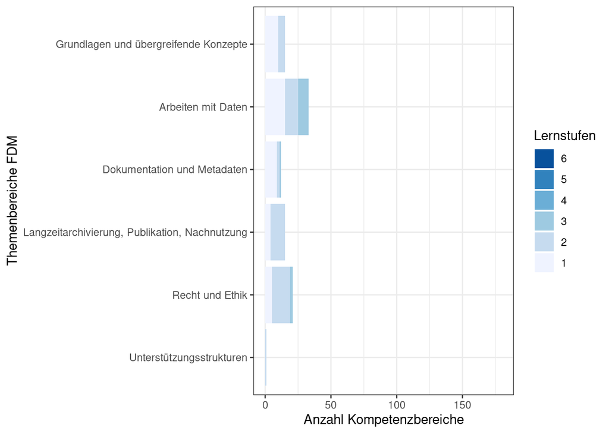

```r
data %>%
  mutate(Kompentenzbereich = recode(Kompentenzbereich, "M"="MK", "Mk" = "MK", "Sok" = "SoK"),
         Level = fct_relevel(Level, "Bachelor", "Master", "PhD", "Data Stewards"),
         FDM.Themenbereich = fct_relevel(FDM.Themenbereich, "Grundlagen und übergreifende Konzepte",
                                         "Arbeiten mit Daten", "Dokumentation und Metadaten",
                                         "Langzeitarchivierung, Publikation, Nachnutzung",
                                         "Recht und Ethik", "Unterstützungsstrukturen"),
         Lernstufe = fct_relevel(Lernstufe, "1", "2", "3", "4", "5", "6")) %>%
  filter(Level == "Bachelor") %>%
  group_by(FDM.Themenbereich, Kompentenzbereich, Lernstufe) %>%
  summarise(count = n()) %>%
  ungroup() %>%
  ggplot(aes(x=FDM.Themenbereich, y = count, fill = forcats::fct_rev(Lernstufe))) +
  geom_bar(position = "stack", stat = "identity") +
  theme_bw() +
  scale_x_discrete(limits=rev) +
  scale_fill_brewer(direction = -1, drop=FALSE) +
  ylim(0,180) +
  labs(x="Themenbereiche FDM", y = "Anzahl Kompetenzbereiche", fill = "Lernstufen") +
  coord_flip()
```

**Master**

- inkl. Bachelor

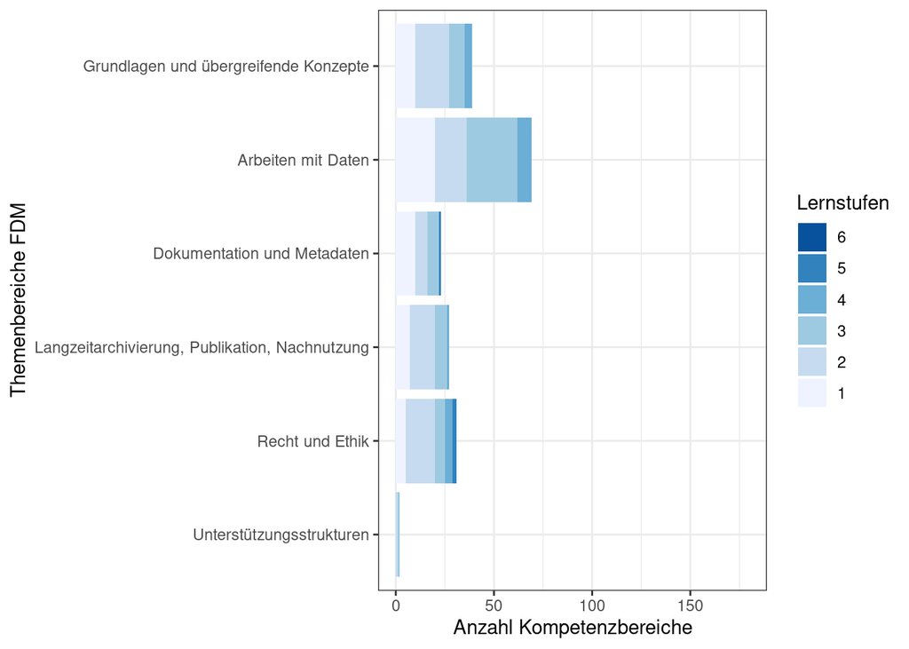

```r
data %>%
  mutate(Kompentenzbereich = recode(Kompentenzbereich, "M"="MK", "Mk" = "MK", "Sok" = "SoK"),
         Level = fct_relevel(Level, "Bachelor", "Master", "PhD", "Data Stewards"),
         FDM.Themenbereich = fct_relevel(FDM.Themenbereich, "Grundlagen und übergreifende Konzepte",
                                         "Arbeiten mit Daten", "Dokumentation und Metadaten",
                                         "Langzeitarchivierung, Publikation, Nachnutzung",
                                         "Recht und Ethik", "Unterstützungsstrukturen"),
         Lernstufe = fct_relevel(Lernstufe, "1", "2", "3", "4", "5", "6")) %>%
  filter(Level == "Bachelor" | Level == "Master") %>%
  group_by(FDM.Themenbereich, Kompentenzbereich, Lernstufe) %>%
  summarise(count = n()) %>%
  ungroup() %>%
  ggplot(aes(x=FDM.Themenbereich, y = count, fill = forcats::fct_rev(Lernstufe))) +
  geom_bar(position = "stack", stat = "identity") +
  theme_bw() +
  scale_x_discrete(limits=rev) +
  scale_fill_brewer(direction = -1, drop=FALSE) +
  ylim(0,180) +
  labs(x="Themenbereiche FDM", y = "Anzahl Kompetenzbereiche", fill = "Lernstufen") +
  coord_flip()
```

**PhD**

- inkl. Bachelor, Master

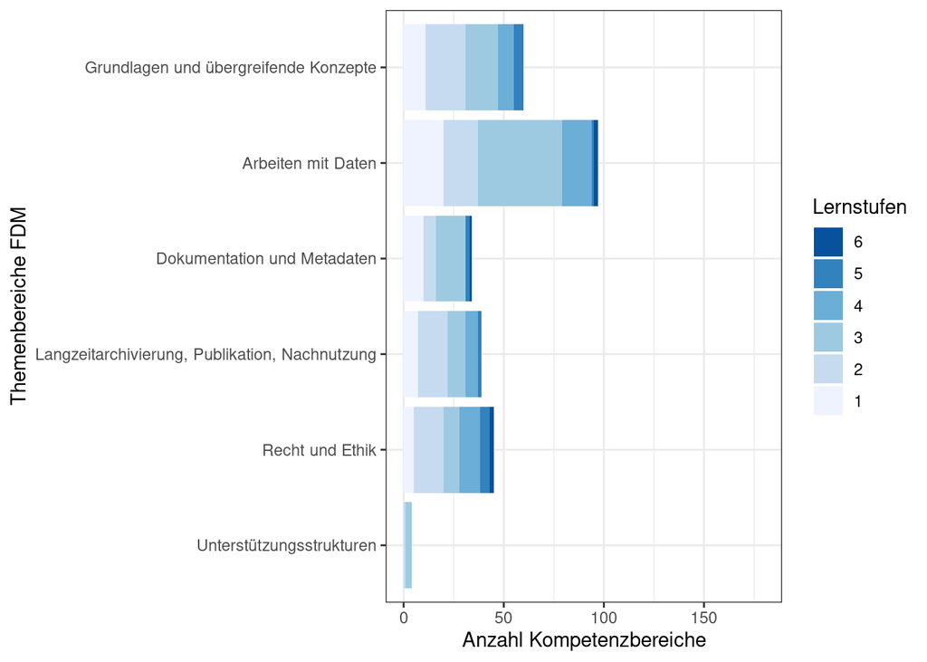

```r
data %>%
  mutate(Kompentenzbereich = recode(Kompentenzbereich, "M"="MK", "Mk" = "MK", "Sok" = "SoK"),
         Level = fct_relevel(Level, "Bachelor", "Master", "PhD", "Data Stewards"),
         FDM.Themenbereich = fct_relevel(FDM.Themenbereich, "Grundlagen und übergreifende Konzepte",
                                         "Arbeiten mit Daten", "Dokumentation und Metadaten",
                                         "Langzeitarchivierung, Publikation, Nachnutzung",
                                         "Recht und Ethik", "Unterstützungsstrukturen"),
         Lernstufe = fct_relevel(Lernstufe, "1", "2", "3", "4", "5", "6")) %>%
  filter(Level == "Bachelor" | Level == "Master" | Level == "PhD") %>%
  group_by(FDM.Themenbereich, Kompentenzbereich, Lernstufe) %>%
  summarise(count = n()) %>%
  ungroup() %>%
  drop_na(Lernstufe) %>%
  ggplot(aes(x=FDM.Themenbereich, y = count, fill = forcats::fct_rev(Lernstufe))) +
  geom_bar(position = "stack", stat = "identity") +
  theme_bw() +
  scale_x_discrete(limits=rev) +
  scale_fill_brewer(direction = -1, drop=FALSE) +
  ylim(0,180) +
  labs(x="Themenbereiche FDM", y = "Anzahl Kompetenzbereiche", fill = "Lernstufen") +
  coord_flip()
```

**Data Stewards**

- inkl. Bachelor, Master, PhD

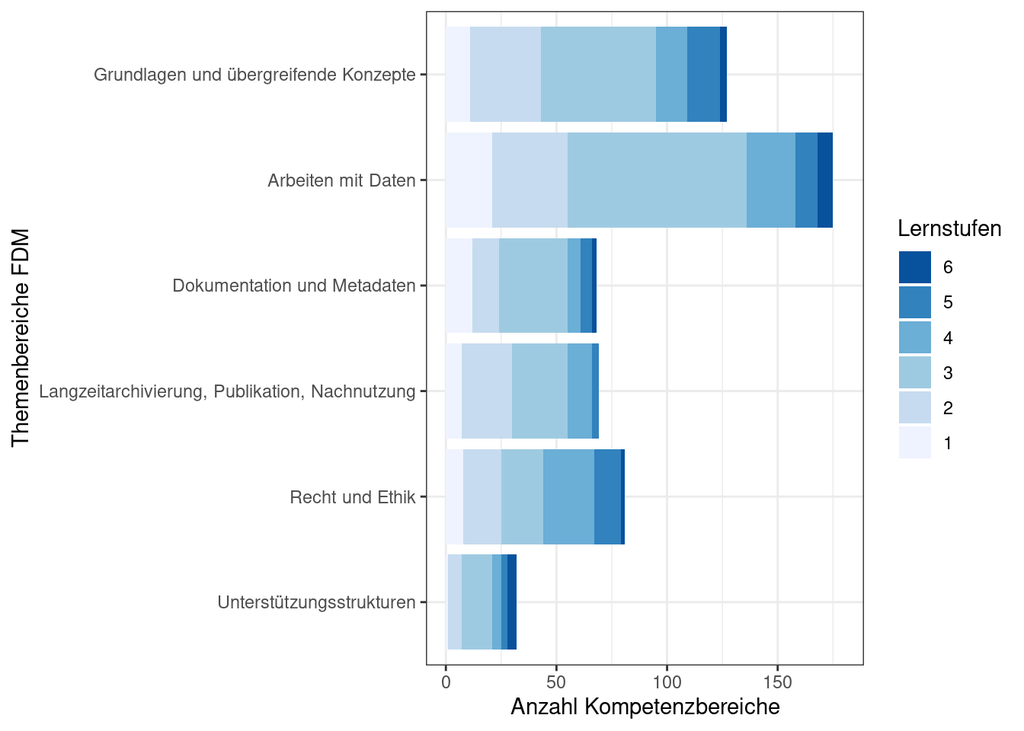

```r
data %>%
  mutate(Kompentenzbereich = recode(Kompentenzbereich, "M"="MK", "Mk" = "MK", "Sok" = "SoK"),
         Level = fct_relevel(Level, "Bachelor", "Master", "PhD", "Data Stewards"),
         FDM.Themenbereich = fct_relevel(FDM.Themenbereich, "Grundlagen und übergreifende Konzepte",
                                         "Arbeiten mit Daten", "Dokumentation und Metadaten",
                                         "Langzeitarchivierung, Publikation, Nachnutzung",
                                         "Recht und Ethik", "Unterstützungsstrukturen"),
         Lernstufe = fct_relevel(Lernstufe, "1", "2", "3", "4", "5", "6")) %>%
  #filter(Level == "Bachelor" | Level == "Master" | Level == "PhD" | Level == "Data Steward") %>%
  group_by(FDM.Themenbereich, Kompentenzbereich, Lernstufe) %>%
  summarise(count = n()) %>%
  ungroup() %>%
  drop_na(Lernstufe) %>%
  ggplot(aes(x=FDM.Themenbereich, y = count, fill = forcats::fct_rev(Lernstufe))) +
  geom_bar(position = "stack", stat = "identity") +
  theme_bw() +
  scale_x_discrete(limits=rev) +
  scale_fill_brewer(direction = -1, drop=FALSE) +
  ylim(0,180) +
  labs(x="Themenbereiche FDM", y = "Anzahl Kompetenzbereiche", fill = "Lernstufen") +
  coord_flip()
```

### Kombinierte Ansicht der 4 Level

In der folgenden Übersicht sind aktuell die Kompetenzen für jedes Level exklusive der vorhergehenden Level dargestellt.

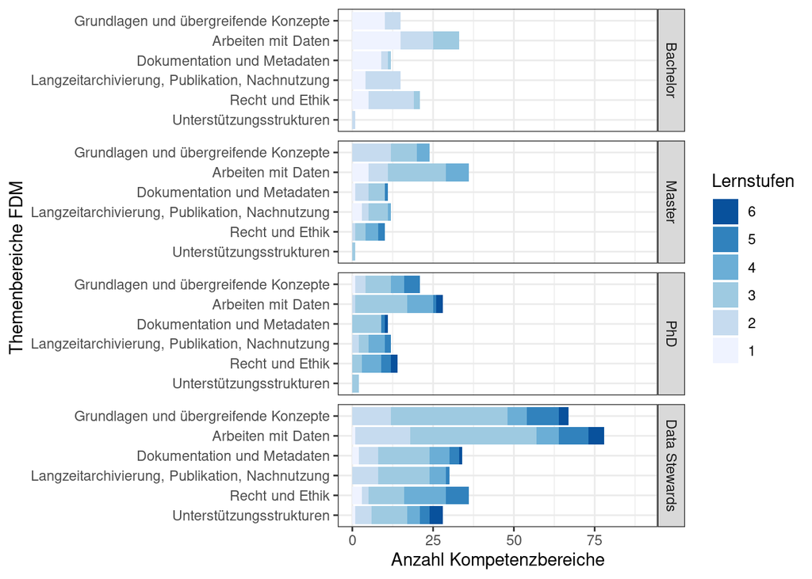

```r
data %>%
  mutate(Kompentenzbereich = recode(Kompentenzbereich, "M"="MK", "Mk" = "MK", "Sok" = "SoK"),
         Level = fct_relevel(Level, "Bachelor", "Master", "PhD", "Data Stewards"),
         FDM.Themenbereich = fct_relevel(FDM.Themenbereich, "Grundlagen und übergreifende Konzepte",
                                         "Arbeiten mit Daten", "Dokumentation und Metadaten",
                                         "Langzeitarchivierung, Publikation, Nachnutzung",
                                         "Recht und Ethik", "Unterstützungsstrukturen"),
         Lernstufe = fct_relevel(Lernstufe, "1", "2", "3", "4", "5", "6")) %>%
  #filter(Level == "Bachelor" | Level == "Master" | Level == "PhD" | Level == "Data Steward") %>%
  group_by(Level, FDM.Themenbereich, Kompentenzbereich, Lernstufe) %>%
  summarise(count = n()) %>%
  ungroup() %>%
  drop_na(Lernstufe) %>%
  ggplot(aes(x=FDM.Themenbereich, y = count, fill = forcats::fct_rev(Lernstufe))) +
  geom_bar(position = "stack", stat = "identity") +
  theme_bw() +
  scale_x_discrete(limits=rev) +
  scale_fill_brewer(direction = -1, drop=FALSE) +
  ylim(0,90) +
  labs(x="Themenbereiche FDM", y = "Anzahl Kompetenzbereiche", fill = "Lernstufen") +
  coord_flip() +
  facet_grid(rows = vars(Level))
```

## Data Stewards Profil

In der DataStew-Publikation (Förstner et al. 2023) werden Profile für verschiedene Data Stewards vorgestellt, welche im Bereich Forschungsdatenmanagement tätig sind. Im Folgenden zeigt sich ein Profil, welches sich aus der Lernzielmatrix ergibt. Es hat noch kein Matching zwischen den in den DataStew-Profilen vorgeschlagenen Kategorien und der hier dargestellten Lernzielmatrix stattgefunden. Dieser Abgleich wäre ein nächster Schritt.

**FDM Themenbereiche**

Profil für Data Stewards über FDM-Themenbereiche mit aufaddierten Kompetenzbereichen.

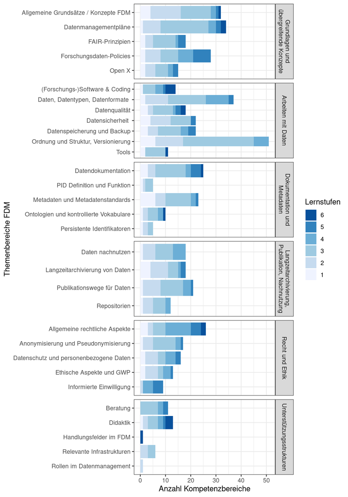

```r
data %>%
  mutate(Kompentenzbereich = recode(Kompentenzbereich, "M"="MK", "Mk" = "MK", "Sok" = "SoK"),
         Level = fct_relevel(Level, "Bachelor", "Master", "PhD", "Data Stewards"),
         FDM.Themenbereich = fct_relevel(FDM.Themenbereich, "Grundlagen und übergreifende Konzepte",
                                         "Arbeiten mit Daten", "Dokumentation und Metadaten",
                                         "Langzeitarchivierung, Publikation, Nachnutzung",
                                         "Recht und Ethik", "Unterstützungsstrukturen"),
         FDM.Sub.Themenbereich = fct_recode(FDM.Sub.Themenbereich,
                                            "Allgemeine Grundsätze / Konzepte FDM" = "Allgemeine Grundsätze und Konzepte des Forschungsdaten-managements",
                                            "Forschungsdaten-Policies" = "Forschungsdaten-Policies",
"Datenmanagementpläne" = "Datenmanagementpläne",
"FAIR-Prinzipien" = "FAIR-Prinzipien",
"Open X" = "Open X (Open Data, Open Source, Open Science, etc.)",
"Ordnung und Struktur, Versionierung" = "Ordnung und Struktur, Versionierung",
"Daten, Datentypen, Datenformate " = "Daten, Datentypen, Datenformate ",
"Datenspeicherung und Backup" = "Datenspeicherung und Backup",
"Datensicherheit " = "Datensicherheit ",
"Datenqualität" = "Datenqualität",
"Tools" = "Tools",
"(Forschungs-)Software & Coding" = "(Forschungs-)Software & Coding",
"Datendokumentation" = "Datendokumentation",
"Metadaten und Metadatenstandards" ="Metadaten und Metadatenstandards",
"Persistente Identifikatoren" ="Persistente Identifikatoren",
"PID Definition und Funktion"= "Definition persistente Identifikatoren (PID); Vor- und Nachteile von PIDs; Funktionen von PIDs; nähere Beschreibung ausgewählter PIDs; Aufbau von PIDs",
"Ontologien und kontrollierte Vokabulare" = "Ontologien und kontrollierte Vokabulare",
"Langzeitarchivierung von Daten" ="Langzeitarchivierung von Daten",
"Publikationswege für Daten" ="Publikationswege für Daten",
"Repositorien" = "Repositorien",
"Daten nachnutzen" = "Daten nachnutzen",
"Allgemeine rechtliche Aspekte" ="Allgemeine rechtliche Aspekte" ,
"Datenschutz und personenbezogene Daten" = "Datenschutz und personenbezogene Daten",
"Informierte Einwilligung" = "Informierte Einwilligung" ,
"Anonymisierung und Pseudonymisierung" = "Anonymisierung und Pseudonymisierung",
"Ethische Aspekte und GWP" = "Ethische Aspekte und Gute Wissenschaftliche Praxis (GWP)",
"Rollen im Datenmanagement" = "Rollen im Datenmanagement / Data Stewardship" ,
"Handlungsfelder im FDM" = "Handlungsfelder im FDM; typische Problemstellungen im beruflichen Zusammenhang" ,
"Relevante Infrastrukturen" = "Relevante Infrastrukturen",
"Didaktik" = "Didaktik" ,
"Beratung" = "Beratung"),
         Lernstufe = fct_relevel(Lernstufe, "1", "2", "3", "4", "5", "6")) %>%
  #filter(Level == "Bachelor" | Level == "Master" | Level == "PhD" | Level == "Data Steward") %>%
  group_by(FDM.Themenbereich, FDM.Sub.Themenbereich, Kompentenzbereich, Lernstufe) %>%
  summarise(count = n()) %>%
  ungroup() %>%
  drop_na(Lernstufe) %>%
  ggplot(aes(x=FDM.Sub.Themenbereich, y = count, fill = forcats::fct_rev(Lernstufe))) +
  geom_bar(position = "stack", stat = "identity") +
  theme_bw() +
  scale_x_discrete(limits=rev) +
  scale_fill_brewer(direction = -1, drop=FALSE) +
  #ylim(0,180) +
  labs(x="Themenbereiche FDM", y = "Anzahl Kompetenzbereiche", fill = "Lernstufen") +
  coord_flip() +
  facet_grid(rows = vars(FDM.Themenbereich), scales = "free",
             labeller = label_wrap_gen(multi_line = TRUE))
```

**Kompetenzbereiche**

**Tip**

Codierung der Kompetenzbereiche:

SK = Sachkompetenz; MK = Methodenkompetenz; SoK = Sozialkompetenz; SeK = Selbstkompetenz

**Gesamt**

Profil für Data Stewards über die Kompetenzbereiche mit entsprechenden Lernstufen (keine Berücksichtigung der FDM-Themenbereiche).

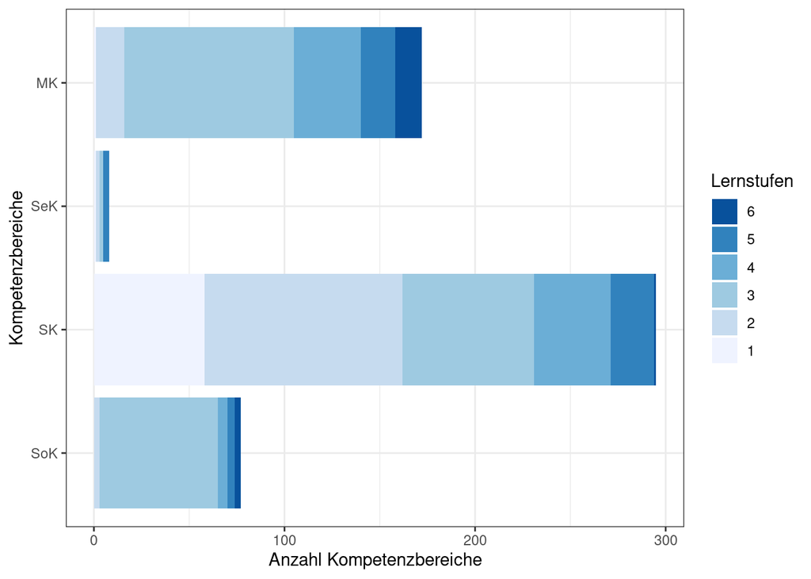

```r
data %>%
  mutate(Kompentenzbereich = recode(Kompentenzbereich, "M"="MK", "Mk" = "MK", "Sok" = "SoK"),
         Level = fct_relevel(Level, "Bachelor", "Master", "PhD", "Data Stewards"),
         FDM.Themenbereich = fct_relevel(FDM.Themenbereich, "Grundlagen und übergreifende Konzepte",
                                         "Arbeiten mit Daten", "Dokumentation und Metadaten",
                                         "Langzeitarchivierung, Publikation, Nachnutzung",
                                         "Recht und Ethik", "Unterstützungsstrukturen"),
         FDM.Sub.Themenbereich = fct_recode(FDM.Sub.Themenbereich,
                                            "Allgemeine Grundsätze / Konzepte FDM" = "Allgemeine Grundsätze und Konzepte des Forschungsdaten-managements",
                                            "Forschungsdaten-Policies" = "Forschungsdaten-Policies",
"Datenmanagementpläne" = "Datenmanagementpläne",
"FAIR-Prinzipien" = "FAIR-Prinzipien",
"Open X" = "Open X (Open Data, Open Source, Open Science, etc.)",
"Ordnung und Struktur, Versionierung" = "Ordnung und Struktur, Versionierung",
"Daten, Datentypen, Datenformate " = "Daten, Datentypen, Datenformate ",
"Datenspeicherung und Backup" = "Datenspeicherung und Backup",
"Datensicherheit " = "Datensicherheit ",
"Datenqualität" = "Datenqualität",
"Tools" = "Tools",
"(Forschungs-)Software & Coding" = "(Forschungs-)Software & Coding",
"Datendokumentation" = "Datendokumentation",
"Metadaten und Metadatenstandards" ="Metadaten und Metadatenstandards",
"Persistente Identifikatoren" ="Persistente Identifikatoren",
"PID Definition und Funktion"= "Definition persistente Identifikatoren (PID); Vor- und Nachteile von PIDs; Funktionen von PIDs; nähere Beschreibung ausgewählter PIDs; Aufbau von PIDs",
"Ontologien und kontrollierte Vokabulare" = "Ontologien und kontrollierte Vokabulare",
"Langzeitarchivierung von Daten" ="Langzeitarchivierung von Daten",
"Publikationswege für Daten" ="Publikationswege für Daten",
"Repositorien" = "Repositorien",
"Daten nachnutzen" = "Daten nachnutzen",
"Allgemeine rechtliche Aspekte" ="Allgemeine rechtliche Aspekte" ,
"Datenschutz und personenbezogene Daten" = "Datenschutz und personenbezogene Daten",
"Informierte Einwilligung" = "Informierte Einwilligung" ,
"Anonymisierung und Pseudonymisierung" = "Anonymisierung und Pseudonymisierung",
"Ethische Aspekte und GWP" = "Ethische Aspekte und Gute Wissenschaftliche Praxis (GWP)",
"Rollen im Datenmanagement" = "Rollen im Datenmanagement / Data Stewardship" ,
"Handlungsfelder im FDM" = "Handlungsfelder im FDM; typische Problemstellungen im beruflichen Zusammenhang" ,
"Relevante Infrastrukturen" = "Relevante Infrastrukturen",
"Didaktik" = "Didaktik" ,
"Beratung" = "Beratung"),
         Lernstufe = fct_relevel(Lernstufe, "1", "2", "3", "4", "5", "6")) %>%
  #filter(Level == "Bachelor" | Level == "Master" | Level == "PhD" | Level == "Data Steward") %>%
  group_by(FDM.Themenbereich, Kompentenzbereich, Lernstufe) %>%
  summarise(count = n()) %>%
  ungroup() %>%
  drop_na(Lernstufe) %>%
  ggplot(aes(x=Kompentenzbereich, y = count, fill = forcats::fct_rev(Lernstufe))) +
  geom_bar(position = "stack", stat = "identity") +
  theme_bw() +
  scale_x_discrete(limits=rev) +
  scale_fill_brewer(direction = -1, drop=FALSE) +
  #ylim(0,180) +
  labs(x="Kompetenzbereiche", y = "Anzahl Kompetenzbereiche", fill = "Lernstufen") +
  coord_flip()
```

**Themenbereiche**

Profil für Data Stewards über die Kompetenzbereiche für die jeweiligen FDM-Themenbereiche.

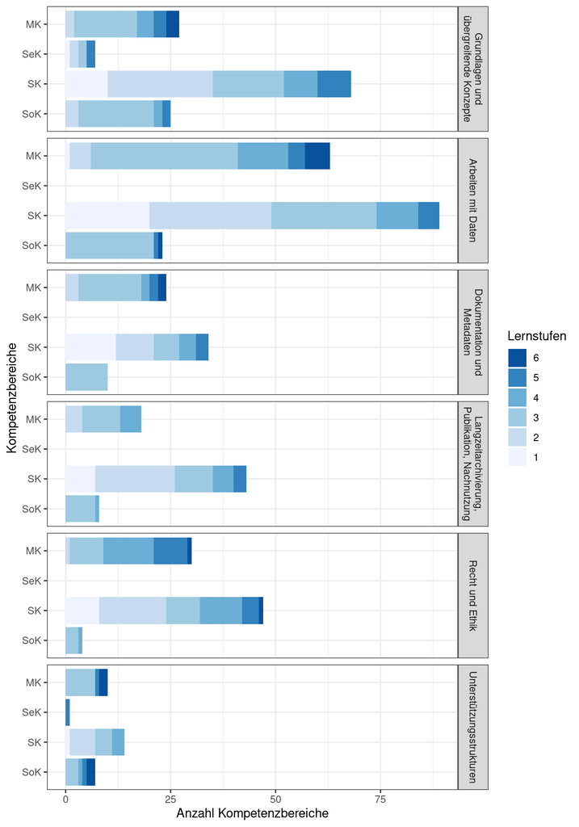

```r
data %>%
  mutate(Kompentenzbereich = recode(Kompentenzbereich, "M"="MK", "Mk" = "MK", "Sok" = "SoK"),
         Level = fct_relevel(Level, "Bachelor", "Master", "PhD", "Data Stewards"),
         FDM.Themenbereich = fct_relevel(FDM.Themenbereich, "Grundlagen und übergreifende Konzepte",
                                         "Arbeiten mit Daten", "Dokumentation und Metadaten",
                                         "Langzeitarchivierung, Publikation, Nachnutzung",
                                         "Recht und Ethik", "Unterstützungsstrukturen"),
         FDM.Sub.Themenbereich = fct_recode(FDM.Sub.Themenbereich,
                                            "Allgemeine Grundsätze / Konzepte FDM" = "Allgemeine Grundsätze und Konzepte des Forschungsdaten-managements",
                                            "Forschungsdaten-Policies" = "Forschungsdaten-Policies",
"Datenmanagementpläne" = "Datenmanagementpläne",
"FAIR-Prinzipien" = "FAIR-Prinzipien",
"Open X" = "Open X (Open Data, Open Source, Open Science, etc.)",
"Ordnung und Struktur, Versionierung" = "Ordnung und Struktur, Versionierung",
"Daten, Datentypen, Datenformate " = "Daten, Datentypen, Datenformate ",
"Datenspeicherung und Backup" = "Datenspeicherung und Backup",
"Datensicherheit " = "Datensicherheit ",
"Datenqualität" = "Datenqualität",
"Tools" = "Tools",
"(Forschungs-)Software & Coding" = "(Forschungs-)Software & Coding",
"Datendokumentation" = "Datendokumentation",
"Metadaten und Metadatenstandards" ="Metadaten und Metadatenstandards",
"Persistente Identifikatoren" ="Persistente Identifikatoren",
"PID Definition und Funktion"= "Definition persistente Identifikatoren (PID); Vor- und Nachteile von PIDs; Funktionen von PIDs; nähere Beschreibung ausgewählter PIDs; Aufbau von PIDs",
"Ontologien und kontrollierte Vokabulare" = "Ontologien und kontrollierte Vokabulare",
"Langzeitarchivierung von Daten" ="Langzeitarchivierung von Daten",
"Publikationswege für Daten" ="Publikationswege für Daten",
"Repositorien" = "Repositorien",
"Daten nachnutzen" = "Daten nachnutzen",
"Allgemeine rechtliche Aspekte" ="Allgemeine rechtliche Aspekte" ,
"Datenschutz und personenbezogene Daten" = "Datenschutz und personenbezogene Daten",
"Informierte Einwilligung" = "Informierte Einwilligung" ,
"Anonymisierung und Pseudonymisierung" = "Anonymisierung und Pseudonymisierung",
"Ethische Aspekte und GWP" = "Ethische Aspekte und Gute Wissenschaftliche Praxis (GWP)",
"Rollen im Datenmanagement" = "Rollen im Datenmanagement / Data Stewardship" ,
"Handlungsfelder im FDM" = "Handlungsfelder im FDM; typische Problemstellungen im beruflichen Zusammenhang" ,
"Relevante Infrastrukturen" = "Relevante Infrastrukturen",
"Didaktik" = "Didaktik" ,
"Beratung" = "Beratung"),
         Lernstufe = fct_relevel(Lernstufe, "1", "2", "3", "4", "5", "6")) %>%
  #filter(Level == "Bachelor" | Level == "Master" | Level == "PhD" | Level == "Data Steward") %>%
  group_by(FDM.Themenbereich, Kompentenzbereich, Lernstufe) %>%
  summarise(count = n()) %>%
  ungroup() %>%
  drop_na(Lernstufe) %>%
  ggplot(aes(x=Kompentenzbereich, y = count, fill = forcats::fct_rev(Lernstufe))) +
  geom_bar(position = "stack", stat = "identity") +
  theme_bw() +
  scale_x_discrete(limits=rev) +
  scale_fill_brewer(direction = -1, drop=FALSE) +
  #ylim(0,180) +
  labs(x="Kompetenzbereiche", y = "Anzahl Kompetenzbereiche", fill = "Lernstufen") +
  coord_flip() +
  facet_grid(rows = vars(FDM.Themenbereich),
             labeller = label_wrap_gen(multi_line = TRUE))
```

## Pakete

```r
#pkgs <- scan_packages()
#get_citations(pkgs$pkg, out.dir = ".", bib.file = "gratefuler-refs")
cite_packages(output = "table", out.dir = ".") %>% kbl(format = "markdown")
```

| Package | Version | Citation |
| --- | --- | --- |
| base | 4.1.2 | R Core Team (2021) |
| kableExtra | 1.3.9.9001 | Zhu (2023) |
| RColorBrewer | 1.1.3 | Neuwirth (2022) |
| rmarkdown | 2.25 | Xie, Allaire, and Grolemund (2018); Xie, Dervieux, and Riederer (2020); Allaire et al. (2023) |
| tidyverse | 2.0.0 | Wickham et al. (2019) |
| xlsx | 0.6.5 | Dragulescu and Arendt (2020) |

## References

Allaire, JJ, Yihui Xie, Christophe Dervieux, Jonathan McPherson, Javier Luraschi, Kevin Ushey, Aron Atkins, et al. 2023. *rmarkdown: Dynamic Documents for r*. https://github.com/rstudio/rmarkdown.

Dragulescu, Adrian, and Cole Arendt. 2020. *xlsx: Read, Write, Format Excel 2007 and Excel 97/2000/XP/2003 Files*. https://CRAN.R-project.org/package=xlsx.

Förstner, Konrad Ulrich, Eva Seidlmayer, ZB MED-Informationszentrum Lebenswissenschaften, Wissenschaft Deutschland. Bundesministerium Für Bildung, Jens Dierkes, Ralf Depping, Technische Hochschule Köln, et al. 2023. “Forschung unterstützen - Empfehlungen für Data Stewardship an akademischen Forschungsinstitutionen.” *PUBLISSO*. https://doi.org/10.4126/FRL01-006441397.

Neuwirth, Erich. 2022. *RColorBrewer: ColorBrewer Palettes*. https://CRAN.R-project.org/package=RColorBrewer.

Petersen, Britta, Claudia Engelhardt, Tanja Hörner, Juliane Jacob, Tatiana Kvetnaya, Andreas Mühlichen, Hermann Schranzhofer, et al. 2022. “Lernzielmatrix zum Themenbereich Forschungsdatenmanagement (FDM) für die Zielgruppen Studierende, PhDs und Data Stewards,” September. https://doi.org/10.5281/ZENODO.7034478.

R Core Team. 2021. *R: A Language and Environment for Statistical Computing*. Vienna, Austria: R Foundation for Statistical Computing. https://www.R-project.org/.

Wickham, Hadley, Mara Averick, Jennifer Bryan, Winston Chang, Lucy D’Agostino McGowan, Romain François, Garrett Grolemund, et al. 2019. “Welcome to the tidyverse.” *Journal of Open Source Software* 4 (43): 1686. https://doi.org/10.21105/joss.01686.

Xie, Yihui, J. J. Allaire, and Garrett Grolemund. 2018. *R Markdown: The Definitive Guide*. Boca Raton, Florida: Chapman; Hall/CRC. https://bookdown.org/yihui/rmarkdown.

Xie, Yihui, Christophe Dervieux, and Emily Riederer. 2020. *R Markdown Cookbook*. Boca Raton, Florida: Chapman; Hall/CRC. https://bookdown.org/yihui/rmarkdown-cookbook.

Zhu, Hao. 2023. *kableExtra: Construct Complex Table with “kable” and Pipe Syntax*.